# Tutorial for Cumulative Link Mixed Models (CLMMs) in R with the package ‘ordinal’

Christophe Bousquet

25/02/2021

# Introduction

Cumulative Link Mixed Models (CLMMs) make it possible to analyse ordinal response variables while allowing the use of random effects.

Ordinal responses are very common, most often in the form of Likert scales (e.g. 1. strongly disagree, 2. disagree, 3. neither agree nor disagree, 4. agree, 5. strongly agree) or preference ranks (e.g. 1. apple, 2. pear, 3. melon).

By allowing the use of random effects, CLMMs enable the inclusion of data collected repeatedly on several subjects or at several study sites.

The example presented here takes the data published by [Bousquet et al. in Behaviour](https://brill.com/view/journals/beh/154/4/article-p467_5.xml) (2017) and shows how to model the effects of different parameters on the order of individuals during collective movements of female mallards.

Briefly, this study sought to determine the factors favouring leadership among those already identified in the literature: energy needs, social relations and personality. In a first step, mallards learned to find food in different compartments at the end of a maze. Each informed duck therefore had a direction preference in the labyrinth. The average time taken by the duck to cross the labyrinth during its solitary training was also recorded. Once this learning phase was over, groups were formed with mallards holding different information in different proportions. The order in which the mallards entered the maze was recorded, as well as the order in which they arrived at the end of the labyrinth. For the order of arrival, we excluded the cases in which the groups split up (72 out of 471).

The retained variables for all experiments are: - Scaled Mass Index of each bird [high values indicate higher needs] - Average exploration score of each bird in the personality tests (3 novel environment tests and 3 novel object tests) [high values indicate more exploratory birds] - Frequency of being the nearest neighbour of another bird [high values indicate social birds] - Average crossing time of the maze during the learning phase [high values indicate slower birds] - Number of passages in the maze, to control for maze exposure

From the second set on, behaviours in the pre-departure area (where the mallards were grouped together for 5 minutes before the opening of the sliding door into the maze) were recorded: - Mobility of each bird during the pre-departure period [high values indicate more mobile birds] - Surface explored by each bird [high values indicate that the bird explored a higher portion of the pre-departure area] - Number of vocalizations [high values indicate more vocal birds] - Time spent foraging - Number of attacks emitted towards other birds - Number of attacks received from other birds - Distance to the door

Other variables are included in the various sets of the experiment, when appropriate.

As all individuals are females that hatched on the same day, sex and age are not taken into account.

As we are interested in the relative effects of these variables in groups of birds, we first compute for each experimental group the difference between each bird’s values and the average values for the corresponding group.

In order to improve the interpretability of the estimates, we scale all numeric variables before adding them to the model.

# A - Setup

## 1. Load the necessary packages to run the script

(use install.packages(“package”) before if the package is not yet installed on your machine)

```r
library(dplyr)
library(tidyr)
library(ordinal)
library(lme4)
library(ggplot2)
library(car)
library(MuMIn)
```

## 2. Import the data

load the files “Leadership_RawResults.csv” and “Leadership_IndividualCharacteristics.csv”

```r
Leadership <- read.csv("Leadership_RawResults.csv", header = TRUE)
Ind_Charac <- read.csv("Leadership_IndividualCharacteristics.csv", header = TRUE)
```

## 3. Join the two datasets

```r
Leadership <- Leadership %>%
  left_join(Ind_Charac, by = "Individual")
```

## 4. Specify which variables are factors

Treating OrderEntrance and OrderEnd as factors is essential to run CLMMs: their response variable has to be (ordered) factors

```r
Leadership$OrderEntrance <- factor(Leadership$OrderEntrance, ordered = TRUE)
Leadership$OrderEntrance4 <- factor(Leadership$OrderEntrance4, ordered = TRUE)
Leadership$OrderEnd <- factor(Leadership$OrderEnd, ordered = TRUE)
Leadership$OrderEnd4 <- factor(Leadership$OrderEnd4, ordered = TRUE)
Leadership$Individual <- factor(Leadership$Individual)
Leadership$Group <- factor(Leadership$Group)
Leadership$OrderAll <- factor(Leadership$OrderAll)
```

## 5. Form subsets for each experimental set

The analysis of OrderEntrance takes into account all events (as all individuals always entered the maze), but the analysis of OrderEnd takes into account only events in which the group did not split up.

In order to produce predictions on new data, it is important to limit the levels of OrderEntrance and OrderEnd to the levels existing in each set. Hence the use of the `droplevels()` function

```r
Set1 <- Leadership %>%
  filter(Set == 1)
Set1$OrderEntrance <- droplevels(Set1$OrderEntrance)
Set1$OrderEnd <- droplevels(Set1$OrderEnd)

Set1_nf <- Leadership %>%
  filter(Set == 1)
Set1_nf$OrderEntrance <- droplevels(Set1_nf$OrderEntrance)
Set1_nf$OrderEnd <- droplevels(Set1_nf$OrderEnd)


Set2 <- Leadership %>%
  filter(Set == 2)
Set2$OrderEntrance <- droplevels(Set2$OrderEntrance)
Set2$OrderEnd <- droplevels(Set2$OrderEnd)

Set2_nf <- Leadership %>%
  filter(Set == 2)
Set2_nf$OrderEntrance <- droplevels(Set2_nf$OrderEntrance)
Set2_nf$OrderEnd <- droplevels(Set2_nf$OrderEnd)


Set3 <- Leadership %>%
  filter(Set == 3)
Set3$OrderEntrance <- droplevels(Set3$OrderEntrance)
Set3$OrderEnd <- droplevels(Set3$OrderEnd)

Set3_nf <- Leadership %>%
  filter(Set == 3)
Set3_nf$OrderEntrance <- droplevels(Set3_nf$OrderEntrance)
Set3_nf$OrderEnd <- droplevels(Set3_nf$OrderEnd)
```

# B - Analysis of leadership using CLMMs in Set1

This set focuses on pairs of female mallards with identical information and rewards.

## 1. create group-level variables (differences between individuals and group average)

```r
Set1 <- Set1 %>%
  group_by(OrderAll) %>%
  mutate(SMI_av = mean(SMI),
         Exp_av = mean(Exploration),
         LTi_av = mean(LearningTime),
         FNN_av = mean(FreqNN),
         NPa_av = mean(NumPas),
         SMI_rel = SMI - SMI_av,
         Exp_rel = Exploration - Exp_av,
         LTi_rel = LearningTime - LTi_av,
         FNN_rel = FreqNN - FNN_av,
         NPa_rel = NumPas - NPa_av)

# scale numerical variables
# the as.numeric() function avoids creating lists
Set1$SMI_rel_s <- as.numeric(scale(Set1$SMI_rel))
Set1$Exp_rel_s <- as.numeric(scale(Set1$Exp_rel))
Set1$LTi_rel_s <- as.numeric(scale(Set1$LTi_rel))
Set1$FNN_rel_s <- as.numeric(scale(Set1$FNN_rel))
Set1$NPa_rel_s <- as.numeric(scale(Set1$NPa_rel))


Set1_nf <- Set1_nf %>%
  group_by(OrderAll) %>%
  mutate(SMI_av = mean(SMI),
         Exp_av = mean(Exploration),
         LTi_av = mean(LearningTime),
         FNN_av = mean(FreqNN),
         NPa_av = mean(NumPas),
         SMI_rel = SMI - SMI_av,
         Exp_rel = Exploration - Exp_av,
         LTi_rel = LearningTime - LTi_av,
         FNN_rel = FreqNN - FNN_av,
         NPa_rel = NumPas - NPa_av)

# scale numerical variables
# the as.numeric() function avoids creating lists
Set1_nf$SMI_rel_s <- as.numeric(scale(Set1_nf$SMI_rel))
Set1_nf$Exp_rel_s <- as.numeric(scale(Set1_nf$Exp_rel))
Set1_nf$LTi_rel_s <- as.numeric(scale(Set1_nf$LTi_rel))
Set1_nf$FNN_rel_s <- as.numeric(scale(Set1_nf$FNN_rel))
Set1_nf$NPa_rel_s <- as.numeric(scale(Set1_nf$NPa_rel))
```

## 2. Analysis of the entrance order in the maze

### 2a. Modelling

First, we create a null model containing only the random effects, here the identifier of the experimental group (OrderAll) and the identifier of each individual (Individual)

```r
CLMM_Entrance_S1_Null <- clmm(OrderEntrance ~ 1 +
                            (1|OrderAll) + (1|Individual), data = Set1)
summary(CLMM_Entrance_S1_Null)
```

```
## Cumulative Link Mixed Model fitted with the Laplace approximation
##
## formula: OrderEntrance ~ 1 + (1 | OrderAll) + (1 | Individual)
## data:    Set1
##
##  link  threshold nobs logLik AIC   niter   max.grad cond.H
##  logit flexible  60   -39.64 85.27 44(135) 5.81e-06 1.3e+00
##
## Random effects:
##  Groups     Name        Variance Std.Dev.
##  OrderAll   (Intercept) 0.000    0.000
##  Individual (Intercept) 1.142    1.069
## Number of groups:  OrderAll 30,  Individual 10
##
## No Coefficients
##
## Threshold coefficients:
##      Estimate Std. Error z value
## 1|2 8.181e-07  4.467e-01       0
```

We can see that the random effect of the experimental group (OrderAll) does not explain any variance, but we keep it to respect the experimental protocol.

Next, we implement the full model with all relevant scaled variables for Set1

```r
CLMM_Entrance_S1_Full <- clmm(OrderEntrance ~ NPa_rel_s + SMI_rel_s + Exp_rel_s + LTi_rel_s + FNN_rel_s +
                               (1|OrderAll) + (1|Individual), data = Set1)
summary(CLMM_Entrance_S1_Full)
```

```
## Cumulative Link Mixed Model fitted with the Laplace approximation
##
## formula: OrderEntrance ~ NPa_rel_s + SMI_rel_s + Exp_rel_s + LTi_rel_s +
##     FNN_rel_s + (1 | OrderAll) + (1 | Individual)
## data:    Set1
##
##  link  threshold nobs logLik AIC   niter    max.grad cond.H
##  logit flexible  60   -29.47 74.94 394(108) 2.73e-05 4.6e+01
##
## Random effects:
##  Groups     Name        Variance  Std.Dev.
##  OrderAll   (Intercept) 0.000e+00 0.000e+00
##  Individual (Intercept) 5.586e-12 2.364e-06
## Number of groups:  OrderAll 30,  Individual 10
##
## Coefficients:
##            Estimate Std. Error z value Pr(>|z|)
## NPa_rel_s -0.513174   0.325678  -1.576   0.1151
## SMI_rel_s -2.340963   1.033486  -2.265   0.0235 *
## Exp_rel_s  1.102365   1.017813   1.083   0.2788
## LTi_rel_s -2.142135   0.940243  -2.278   0.0227 *
## FNN_rel_s  0.006204   0.316880   0.020   0.9844
## ---
## Signif. codes:  0 '***' 0.001 '**' 0.01 '*' 0.05 '.' 0.1 ' ' 1
##
## Threshold coefficients:
##       Estimate Std. Error z value
## 1|2 -2.035e-06  3.223e-01       0
```

By conducting backwards elimination of non-significant terms, we arrive to a minimal model.

```r
CLMM_Entrance_S1_Min_temp <- clmm(OrderEntrance ~ NPa_rel_s + SMI_rel_s + Exp_rel_s + LTi_rel_s +
                               (1|OrderAll) + (1|Individual), data = Set1)
anova(CLMM_Entrance_S1_Full, CLMM_Entrance_S1_Min_temp)
```

```
## Likelihood ratio tests of cumulative link models:
##
##                           formula:
## CLMM_Entrance_S1_Min_temp OrderEntrance ~ NPa_rel_s + SMI_rel_s + Exp_rel_s + LTi_rel_s + (1 | OrderAll) + (1 | Individual)
## CLMM_Entrance_S1_Full     OrderEntrance ~ NPa_rel_s + SMI_rel_s + Exp_rel_s + LTi_rel_s + FNN_rel_s + (1 | OrderAll) + (1 | Individual)
##                           link: threshold:
## CLMM_Entrance_S1_Min_temp logit flexible
## CLMM_Entrance_S1_Full     logit flexible
##
##                           no.par    AIC  logLik LR.stat df Pr(>Chisq)
## CLMM_Entrance_S1_Min_temp      7 72.942 -29.471
## CLMM_Entrance_S1_Full          8 74.941 -29.471   4e-04  1     0.9844
```

```r
CLMM_Entrance_S1_Min_temp2 <- clmm(OrderEntrance ~ NPa_rel_s + SMI_rel_s + LTi_rel_s +
                               (1|OrderAll) + (1|Individual), data = Set1)
anova(CLMM_Entrance_S1_Min_temp, CLMM_Entrance_S1_Min_temp2)
```

```
## Likelihood ratio tests of cumulative link models:
##
##                            formula:
## CLMM_Entrance_S1_Min_temp2 OrderEntrance ~ NPa_rel_s + SMI_rel_s + LTi_rel_s + (1 | OrderAll) + (1 | Individual)
## CLMM_Entrance_S1_Min_temp  OrderEntrance ~ NPa_rel_s + SMI_rel_s + Exp_rel_s + LTi_rel_s + (1 | OrderAll) + (1 | Individual)
##                            link: threshold:
## CLMM_Entrance_S1_Min_temp2 logit flexible
## CLMM_Entrance_S1_Min_temp  logit flexible
##
##                            no.par    AIC  logLik LR.stat df Pr(>Chisq)
## CLMM_Entrance_S1_Min_temp2      6 72.167 -30.084
## CLMM_Entrance_S1_Min_temp       7 72.942 -29.471  1.2257  1     0.2683
```

```r
CLMM_Entrance_S1_Min <- clmm(OrderEntrance ~ SMI_rel_s + LTi_rel_s +
                               (1|OrderAll) + (1|Individual), data = Set1)
anova(CLMM_Entrance_S1_Min_temp2, CLMM_Entrance_S1_Min)
```

```
## Likelihood ratio tests of cumulative link models:
##
##                            formula:
## CLMM_Entrance_S1_Min       OrderEntrance ~ SMI_rel_s + LTi_rel_s + (1 | OrderAll) + (1 | Individual)
## CLMM_Entrance_S1_Min_temp2 OrderEntrance ~ NPa_rel_s + SMI_rel_s + LTi_rel_s + (1 | OrderAll) + (1 | Individual)
##                            link: threshold:
## CLMM_Entrance_S1_Min       logit flexible
## CLMM_Entrance_S1_Min_temp2 logit flexible
##
##                            no.par    AIC  logLik LR.stat df Pr(>Chisq)
## CLMM_Entrance_S1_Min            5 72.592 -31.296
## CLMM_Entrance_S1_Min_temp2      6 72.167 -30.084  2.4245  1     0.1195
```

```r
summary(CLMM_Entrance_S1_Min)
```

```
## Cumulative Link Mixed Model fitted with the Laplace approximation
##
## formula: OrderEntrance ~ SMI_rel_s + LTi_rel_s + (1 | OrderAll) + (1 |
##     Individual)
## data:    Set1
##
##  link  threshold nobs logLik AIC   niter  max.grad cond.H
##  logit flexible  60   -31.30 72.59 93(31) 7.12e-05 2.5e+00
##
## Random effects:
##  Groups     Name        Variance  Std.Dev.
##  OrderAll   (Intercept) 0.000e+00 0.000e+00
##  Individual (Intercept) 1.179e-13 3.434e-07
## Number of groups:  OrderAll 30,  Individual 10
##
## Coefficients:
##           Estimate Std. Error z value Pr(>|z|)
## SMI_rel_s  -1.3479     0.4085  -3.299 0.000969 ***
## LTi_rel_s  -1.0934     0.3528  -3.099 0.001943 **
## ---
## Signif. codes:  0 '***' 0.001 '**' 0.01 '*' 0.05 '.' 0.1 ' ' 1
##
## Threshold coefficients:
##      Estimate Std. Error z value
## 1|2 -2.96e-06   3.11e-01       0
```

### 2b. Visualization of the effects

To visualize the effects, we cannot use the `clmm()` function (at the time of writing), but we have to use the `clmm2()` function, which authorizes only 1 random effect to be specified. Its syntax is slightly different. We have to specify `Hess = TRUE` to get a summary.

```r
CLMM2_Entrance_S1_min <- clmm2(OrderEntrance ~ SMI_rel_s + LTi_rel_s,
                               random = Individual, Hess = TRUE, data = Set1)
summary(CLMM2_Entrance_S1_min)
```

```
## Cumulative Link Mixed Model fitted with the Laplace approximation
##
## Call:
## clmm2(location = OrderEntrance ~ SMI_rel_s + LTi_rel_s, random = Individual,
##     data = Set1, Hess = TRUE)
##
## Random effects:
##                     Var     Std.Dev
## Individual 1.023205e-06 0.001011536
##
## Location coefficients:
##           Estimate Std. Error z value Pr(>|z|)
## SMI_rel_s -1.3479   0.4085    -3.2994 0.00096901
## LTi_rel_s -1.0934   0.3528    -3.0989 0.00194266
##
## No scale coefficients
##
## Threshold coefficients:
##     Estimate Std. Error z value
## 1|2  0.0000   0.3110     0.0000
##
## log-likelihood: -31.29586
## AIC: 70.59173
## Condition number of Hessian: 1063487.25
```

We can now predict values on new data, which will cover the whole parameter space of SMI_rel_s and LTi_rel_s.

```r
newdata_Set1_Entrance <- expand.grid(SMI_rel = seq(from = -100,
                                                   to = 100,
                                                   by = 10),
                                     LTi_rel = seq(from = -80,
                                                   to = 80,
                                                   by = 10))

# the next two lines enable to report the data on the scaled units
newdata_Set1_Entrance$SMI_rel_s <- (newdata_Set1_Entrance$SMI_rel - mean(Set1$SMI_rel)) / sd(Set1$SMI_rel)
newdata_Set1_Entrance$LTi_rel_s <- (newdata_Set1_Entrance$LTi_rel - mean(Set1$LTi_rel)) / sd(Set1$LTi_rel)
```

Now, we predict the values for the new data based on the modelling approach. The `sapply()` is important to get the results for each of the two outcomes (first or second in the pair order).

```r
predict_Set1_Entrance <- sapply(as.character(1:2),
                       function(x) {
                         newdata1 = expand.grid(SMI_rel_s = seq(from = min(newdata_Set1_Entrance$SMI_rel_s),
                                                                to = max(newdata_Set1_Entrance$SMI_rel_s),
                                                                by =  max(newdata_Set1_Entrance$SMI_rel_s) - max(newdata_Set1_Entrance[newdata_Set1_Entrance$SMI_rel_s != max(newdata_Set1_Entrance$SMI_rel_s), ]$SMI_rel_s)),
                                                LTi_rel_s = seq(from = min(newdata_Set1_Entrance$LTi_rel_s),
                                                                to = max(newdata_Set1_Entrance$LTi_rel_s),
                                                                by =  max(newdata_Set1_Entrance$LTi_rel_s) - max(newdata_Set1_Entrance[newdata_Set1_Entrance$LTi_rel_s != max(newdata_Set1_Entrance$LTi_rel_s), ]$LTi_rel_s)),
                                                OrderEntrance = factor(x, levels = levels(Set1$OrderEntrance)))
                         predict(CLMM2_Entrance_S1_min, newdata = newdata1) })

# bind together the new data and the predicted values
predict_Set1_Entrance <- cbind(newdata_Set1_Entrance, predict_Set1_Entrance)

# pass the dataframe in a long format
predict_Set1_Entrance <- predict_Set1_Entrance %>%
  gather("1", "2", key = "Rank", value = "prob")
```

As two numerical variables influence the entrance order, it is easier to visualise the respective effects if we extract specific values (min, 0 and max) of one of the two variables. Then, we can plot the effects by using `ggplot2`.

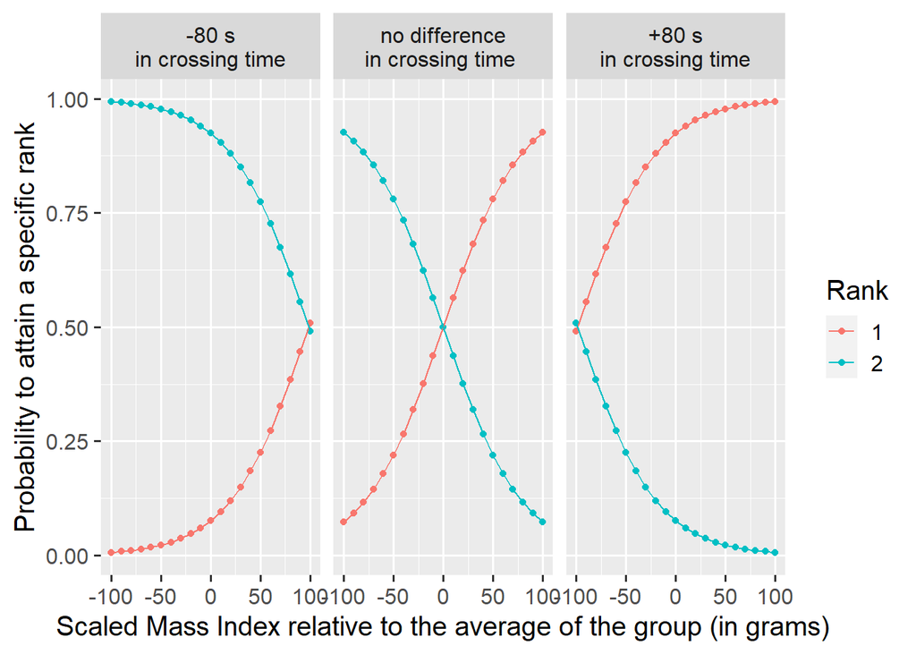

```r
predict_Set1_Entrancebis <- predict_Set1_Entrance %>%
  filter(LTi_rel == min(LTi_rel) |
           LTi_rel == 0 |
           LTi_rel == max(LTi_rel))

LTi_rel.labs <- c("-80 s\nin crossing time", "no difference\nin crossing time ", "+80 s\nin crossing time")
names(LTi_rel.labs) <- c("-80", "0", "80")

predict_Set1_Entrancebis %>%
  ggplot(aes(x = SMI_rel, y = prob, colour = Rank)) +
  geom_point() +
  geom_line() +
  facet_grid(~ LTi_rel, labeller = labeller(LTi_rel = LTi_rel.labs)) +
  labs(x = "Scaled Mass Index relative to the average of the group (in grams)",
       y = "Probability to attain a specific rank") +
  theme_gray(base_size = 15)
```

By plotting the random effect of the identity of the mallards, we can verify that there is indeed not a single individual whose 95% confidence interval does not contain 0: not a single female mallard behaved very differently from the others.

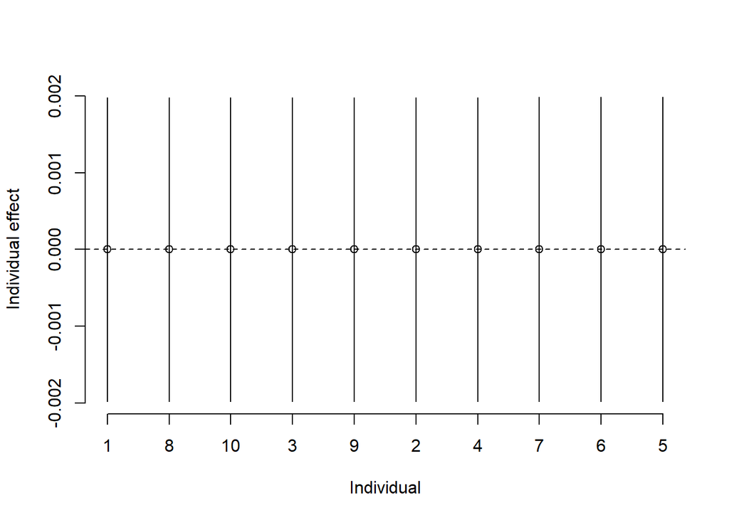

```r
ci_Set1_Entrance <- CLMM2_Entrance_S1_min$ranef + qnorm(0.975) * sqrt(CLMM2_Entrance_S1_min$condVar) %o% c(-1, 1)
ord.re_Set1_Entrance <- order(CLMM2_Entrance_S1_min$ranef)
ci_Set1_Entrance <- ci_Set1_Entrance[order(CLMM2_Entrance_S1_min$ranef), ]
plot(1:10, CLMM2_Entrance_S1_min$ranef[ord.re_Set1_Entrance], axes = FALSE, ylim = range(ci_Set1_Entrance),
     xlab = "Individual", ylab = "Individual effect")
axis(1, at = 1:10, labels = ord.re_Set1_Entrance)
axis(2)
for(i in 1:10) segments(i, ci_Set1_Entrance[i, 1], i, ci_Set1_Entrance[i, 2])
abline(h = 0, lty = 2)
```

### 2c. Side note on the equivalence between logistic regression and CLMMs when the ordinal variable has only two levels

When the ordinal variable has only two levels, there is an equivalence between the cumulative link approach and the logistic regression. To run a mixed-effects logistic regression, we will use the `glmer()` from the R package `lme4` and follow the same steps.

First, we compute a null model.

```r
GLMER_Entrance_S1_Null <- glmer(OrderEntrance ~ 1 +
                              (1|OrderAll) + (1|Individual), family = "binomial", data = Set1)
```

```
## boundary (singular) fit: see ?isSingular
```

```r
summary(GLMER_Entrance_S1_Null)
```

```
## Generalized linear mixed model fit by maximum likelihood (Laplace
##   Approximation) [glmerMod]
##  Family: binomial  ( logit )
## Formula: OrderEntrance ~ 1 + (1 | OrderAll) + (1 | Individual)
##    Data: Set1
##
##      AIC      BIC   logLik deviance df.resid
##     85.3     91.6    -39.6     79.3       57
##
## Scaled residuals:
##     Min      1Q  Median      3Q     Max
## -1.5487 -0.8085  0.0000  0.8085  1.5487
##
## Random effects:
##  Groups     Name        Variance  Std.Dev.
##  OrderAll   (Intercept) 1.595e-10 1.263e-05
##  Individual (Intercept) 1.143e+00 1.069e+00
## Number of obs: 60, groups:  OrderAll, 30; Individual, 10
##
## Fixed effects:
##               Estimate Std. Error z value Pr(>|z|)
## (Intercept) -2.706e-06  4.451e-01       0        1
## optimizer (Nelder_Mead) convergence code: 0 (OK)
## boundary (singular) fit: see ?isSingular
```

Again, the OrderAll random effect explain no variance, but we keep it to respect the experimental protocol.

Then, we compute the full model. In order to analyze the probability to be the leader, we need to respecify the response variable: the binary response variable used in the logistic regression has the value 1 when the individual was first and 0 when the individual was second. That is what the bit `ifelse(OrderEntrance == 1, 1, 0)` does. The argument `na.action = na.fail` is only necessary because we will later use the `dredge()` from the R package `MuMIn`.

```r
GLMER_Entrance_S1_Full <- glmer(ifelse(OrderEntrance == 1, 1, 0) ~ NPa_rel_s + SMI_rel_s + Exp_rel_s + LTi_rel_s + FNN_rel_s +
                                  (1|OrderAll) + (1|Individual), family = "binomial", data = Set1, na.action = na.fail)
```

```
## boundary (singular) fit: see ?isSingular
```

```r
summary(GLMER_Entrance_S1_Full)
```

```
## Generalized linear mixed model fit by maximum likelihood (Laplace
##   Approximation) [glmerMod]
##  Family: binomial  ( logit )
## Formula:
## ifelse(OrderEntrance == 1, 1, 0) ~ NPa_rel_s + SMI_rel_s + Exp_rel_s +
##     LTi_rel_s + FNN_rel_s + (1 | OrderAll) + (1 | Individual)
##    Data: Set1
##
##      AIC      BIC   logLik deviance df.resid
##     74.9     91.7    -29.5     58.9       52
##
## Scaled residuals:
##     Min      1Q  Median      3Q     Max
## -3.4519 -0.5293  0.0000  0.5293  3.4519
##
## Random effects:
##  Groups     Name        Variance Std.Dev.
##  OrderAll   (Intercept) 0        0
##  Individual (Intercept) 0        0
## Number of obs: 60, groups:  OrderAll, 30; Individual, 10
##
## Fixed effects:
##               Estimate Std. Error z value Pr(>|z|)
## (Intercept) -7.263e-10  3.223e-01   0.000   1.0000
## NPa_rel_s    5.132e-01  3.257e-01   1.576   0.1151
## SMI_rel_s    2.341e+00  1.033e+00   2.265   0.0235 *
## Exp_rel_s   -1.102e+00  1.018e+00  -1.083   0.2788
## LTi_rel_s    2.142e+00  9.402e-01   2.278   0.0227 *
## FNN_rel_s   -6.203e-03  3.169e-01  -0.020   0.9844
## ---
## Signif. codes:  0 '***' 0.001 '**' 0.01 '*' 0.05 '.' 0.1 ' ' 1
##
## Correlation of Fixed Effects:
##           (Intr) NP_rl_ SMI_r_ Exp_r_ LT_rl_
## NPa_rel_s  0.000
## SMI_rel_s  0.000  0.079
## Exp_rel_s  0.000 -0.073 -0.915
## LTi_rel_s  0.000  0.202  0.906 -0.911
## FNN_rel_s  0.000  0.074 -0.173  0.149 -0.117
## optimizer (Nelder_Mead) convergence code: 0 (OK)
## boundary (singular) fit: see ?isSingular
```

By using the `glmer()` framework, we can apply the `vif()` function from the R package `car` in order to assess the Variance Inflation Factor associated to each factor.

```r
vif(GLMER_Entrance_S1_Full)
```

```
## NPa_rel_s SMI_rel_s Exp_rel_s LTi_rel_s FNN_rel_s
##  1.153608  7.831404  8.270447  8.367462  1.044978
```

The `glmer()` framework also allows the use of the `dredge()` function, which report the best candidate models (we only print the models with delta < 2).

```r
GLMER_Entrance_S1_dredge <- dredge(GLMER_Entrance_S1_Full)
GLMER_Entrance_S1_dredge[GLMER_Entrance_S1_dredge$delta < 2]
```

```
## Global model call: glmer(formula = ifelse(OrderEntrance == 1, 1, 0) ~ NPa_rel_s +
##     SMI_rel_s + Exp_rel_s + LTi_rel_s + FNN_rel_s + (1 | OrderAll) +
##     (1 | Individual), data = Set1, family = "binomial", na.action = na.fail)
## ---
## Model selection table
##         (Int) Exp_rel_s LTi_rel_s NPa_rel_s SMI_rel_s df  logLik AICc delta
## 21 -3.109e-09               1.093               1.348  5 -31.296 73.7  0.00
## 29 -1.835e-09               1.228    0.4928     1.339  6 -30.084 73.8  0.05
## 30 -6.390e-10   -1.0990     2.140    0.5137     2.337  7 -29.471 75.1  1.39
## 22 -1.549e-09   -0.9183     1.841               2.181  6 -30.839 75.3  1.56
##    weight
## 21  0.341
## 29  0.333
## 30  0.170
## 22  0.156
## Models ranked by AICc(x)
## Random terms (all models):
## '1 | OrderAll', '1 | Individual'
```

The best model is again the one containing only the scaled mass index and the average learning time, even though the model including also the number of passages is very close to it.

The minimal model is the following:

```r
GLMER_Entrance_S1_min <- glmer(ifelse(OrderEntrance == 1, 1, 0) ~ SMI_rel_s + LTi_rel_s +
                                  (1|OrderAll) + (1|Individual), family = "binomial", data = Set1)
```

```
## boundary (singular) fit: see ?isSingular
```

```r
summary(GLMER_Entrance_S1_min)
```

```
## Generalized linear mixed model fit by maximum likelihood (Laplace
##   Approximation) [glmerMod]
##  Family: binomial  ( logit )
## Formula: ifelse(OrderEntrance == 1, 1, 0) ~ SMI_rel_s + LTi_rel_s + (1 |
##     OrderAll) + (1 | Individual)
##    Data: Set1
##
##      AIC      BIC   logLik deviance df.resid
##     72.6     83.1    -31.3     62.6       55
##
## Scaled residuals:
##    Min     1Q Median     3Q    Max
## -2.930 -0.583  0.000  0.583  2.930
##
## Random effects:
##  Groups     Name        Variance Std.Dev.
##  OrderAll   (Intercept) 0        0
##  Individual (Intercept) 0        0
## Number of obs: 60, groups:  OrderAll, 30; Individual, 10
##
## Fixed effects:
##               Estimate Std. Error z value Pr(>|z|)
## (Intercept) -3.109e-09  3.110e-01   0.000 1.000000
## SMI_rel_s    1.348e+00  4.085e-01   3.299 0.000969 ***
## LTi_rel_s    1.093e+00  3.528e-01   3.099 0.001943 **
## ---
## Signif. codes:  0 '***' 0.001 '**' 0.01 '*' 0.05 '.' 0.1 ' ' 1
##
## Correlation of Fixed Effects:
##           (Intr) SMI_r_
## SMI_rel_s 0.000
## LTi_rel_s 0.000  0.411
## optimizer (Nelder_Mead) convergence code: 0 (OK)
## boundary (singular) fit: see ?isSingular
```

In this model, the VIF of both variables are much more acceptable.

```r
vif(GLMER_Entrance_S1_min)
```

```
## SMI_rel_s LTi_rel_s
##  1.203798  1.203798
```

We can now plot the predictions of the model on new data, but this time only the probability to be the leader is plotted (because we run a logistic regression).

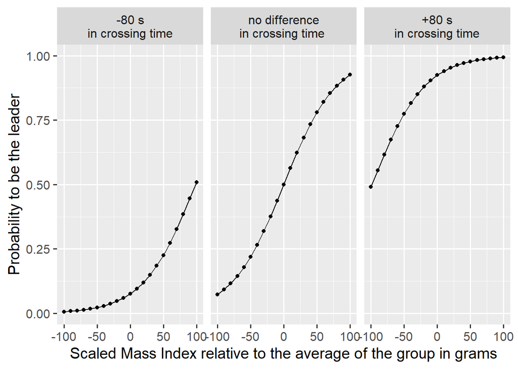

```r
predict_Set1_Entrance_glmer <- cbind(newdata_Set1_Entrance,
                                     prob = predict(GLMER_Entrance_S1_min, newdata = newdata_Set1_Entrance,
                                                    type = "response", re.form = NA))

predict_Set1_Entrance_glmer_bis <- predict_Set1_Entrance_glmer %>%
  filter(LTi_rel == min(LTi_rel) |
           LTi_rel == 0 |
           LTi_rel == max(LTi_rel))

LTi_rel.labs <- c("-80 s\nin crossing time", "no difference\nin crossing time ", "+80 s\nin crossing time")
names(LTi_rel.labs) <- c("-80", "0", "80")

predict_Set1_Entrance_glmer_bis %>%
  ggplot(aes(x = SMI_rel, y = prob)) +
  geom_point() +
  geom_line() +
  facet_grid(~ LTi_rel, labeller = labeller(LTi_rel = LTi_rel.labs)) +
  labs(x = "Scaled Mass Index relative to the average of the group in grams",
       y = "Probability to be the leader") +
  theme_gray(base_size = 15)
```

We can also verify that the residuals of the model do not behave weirdly with any of the explanatory variables (the confidence intervals always contain 0).

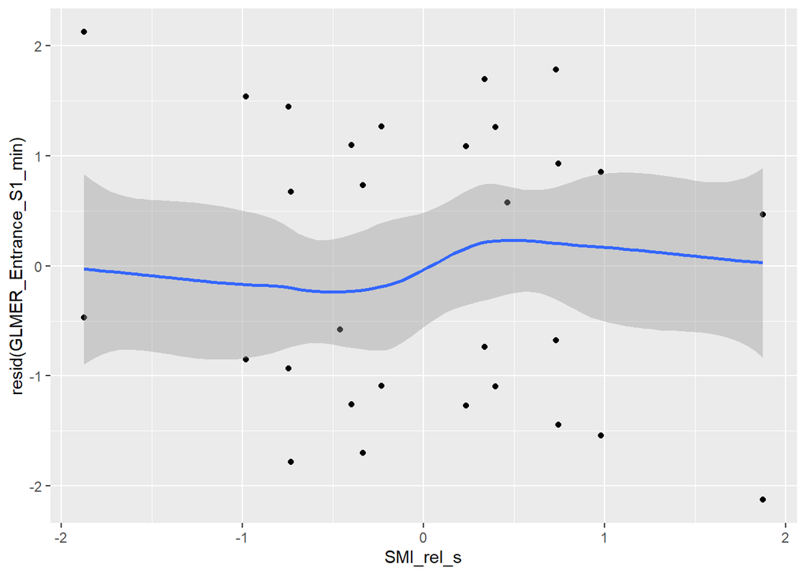

```r
Set1 %>%
  ggplot(aes(x = SMI_rel_s, y = resid(GLMER_Entrance_S1_min))) +
  geom_point() +
  geom_smooth()
```

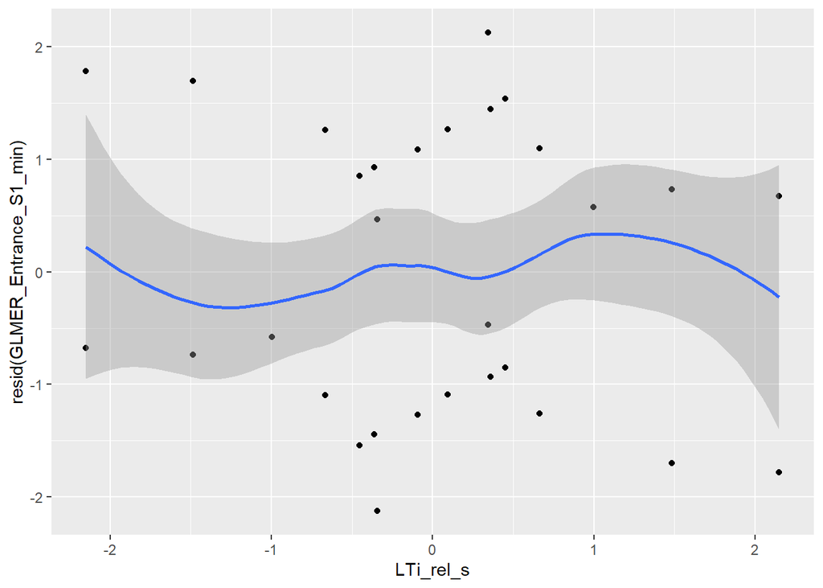

```r
Set1 %>%
  ggplot(aes(x = LTi_rel_s, y = resid(GLMER_Entrance_S1_min))) +
  geom_point() +
  geom_smooth()
```

## 3. Analysis of the order at the end of the maze

For this analysis, the same approach is taken, but this time focusing on cases without group fission.

```r
# Null CLMM
CLMM_End_S1_Null <- clmm(OrderEnd ~ 1 +
                           (1|OrderAll) + (1|Individual), data = Set1_nf)
summary(CLMM_End_S1_Null)
```

```
## Cumulative Link Mixed Model fitted with the Laplace approximation
##
## formula: OrderEnd ~ 1 + (1 | OrderAll) + (1 | Individual)
## data:    Set1_nf
##
##  link  threshold nobs logLik AIC   niter   max.grad cond.H
##  logit flexible  60   -36.82 79.64 67(268) 1.14e-05 1.3e+00
##
## Random effects:
##  Groups     Name        Variance  Std.Dev.
##  OrderAll   (Intercept) 2.813e-13 5.304e-07
##  Individual (Intercept) 2.644e+00 1.626e+00
## Number of groups:  OrderAll 30,  Individual 10
##
## No Coefficients
##
## Threshold coefficients:
##     Estimate Std. Error z value
## 1|2  0.05516    0.61650   0.089
```

```r
# Full CLMM
CLMM_End_S1_Full <- clmm(OrderEnd ~ NPa_rel_s + SMI_rel_s + Exp_rel_s + LTi_rel_s + FNN_rel_s +
                           (1|OrderAll) + (1|Individual), data = Set1_nf)
summary(CLMM_End_S1_Full)
```

```
## Cumulative Link Mixed Model fitted with the Laplace approximation
##
## formula:
## OrderEnd ~ NPa_rel_s + SMI_rel_s + Exp_rel_s + LTi_rel_s + FNN_rel_s +
##     (1 | OrderAll) + (1 | Individual)
## data:    Set1_nf
##
##  link  threshold nobs logLik AIC   niter    max.grad cond.H
##  logit flexible  60   -27.42 70.83 320(343) 9.78e-05 4.0e+01
##
## Random effects:
##  Groups     Name        Variance  Std.Dev.
##  OrderAll   (Intercept) 0.000e+00 0.000e+00
##  Individual (Intercept) 5.419e-09 7.361e-05
## Number of groups:  OrderAll 30,  Individual 10
##
## Coefficients:
##           Estimate Std. Error z value Pr(>|z|)
## NPa_rel_s -0.15608    0.33255  -0.469  0.63883
## SMI_rel_s -1.37234    1.09719  -1.251  0.21101
## Exp_rel_s  0.01164    0.94716   0.012  0.99020
## LTi_rel_s -0.60049    0.81057  -0.741  0.45880
## FNN_rel_s  1.85263    0.57769   3.207  0.00134 **
## ---
## Signif. codes:  0 '***' 0.001 '**' 0.01 '*' 0.05 '.' 0.1 ' ' 1
##
## Threshold coefficients:
##       Estimate Std. Error z value
## 1|2 -3.739e-06  3.292e-01       0
```

```r
CLMM2_End_S1_min <- clmm2(OrderEnd ~ FNN_rel_s,
                           random = Individual, Hess = TRUE, data = Set1_nf)
summary(CLMM2_End_S1_min)
```

```
## Cumulative Link Mixed Model fitted with the Laplace approximation
##
## Call:
## clmm2(location = OrderEnd ~ FNN_rel_s, random = Individual, data = Set1_nf,
##     Hess = TRUE)
##
## Random effects:
##                  Var   Std.Dev
## Individual 0.7577381 0.8704816
##
## Location coefficients:
##           Estimate Std. Error z value Pr(>|z|)
## FNN_rel_s 1.6197   0.5095     3.1787  0.0014796
##
## No scale coefficients
##
## Threshold coefficients:
##     Estimate Std. Error z value
## 1|2 0.0168   0.4402     0.0382
##
## log-likelihood: -30.40658
## AIC: 66.81316
## Condition number of Hessian: 2.630149
```

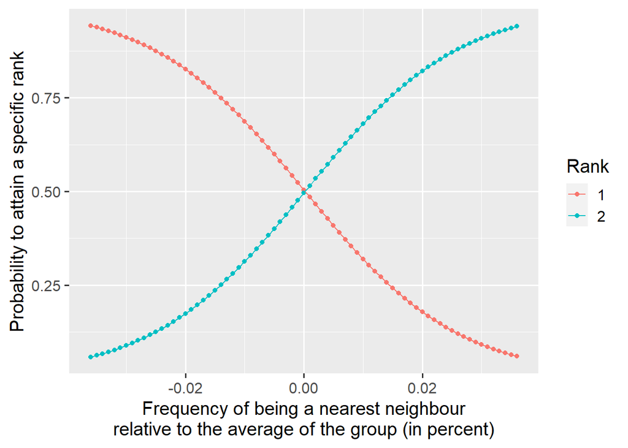

```r
newdata_Set1_End <- expand.grid(FNN_rel = seq(from = -0.036,
                                                   to = 0.036,
                                                   by = 0.001))

# the next line enables to report the data on the scaled units
newdata_Set1_End$FNN_rel_s <- (newdata_Set1_End$FNN_rel - mean(Set1_nf$FNN_rel)) / sd(Set1_nf$FNN_rel)

predict_Set1_End <- sapply(as.character(1:2),
                            function(x) {
                              newdata1 = expand.grid(FNN_rel_s = seq(from = min(newdata_Set1_End$FNN_rel_s),
                                                                     to = max(newdata_Set1_End$FNN_rel_s),
                                                                     by =  max(newdata_Set1_End$FNN_rel_s) - max(newdata_Set1_End[newdata_Set1_End$FNN_rel_s != max(newdata_Set1_End$FNN_rel_s), ]$FNN_rel_s)),
                                                     OrderEnd = factor(x, levels = levels(Set1$OrderEnd)))
                              predict(CLMM2_End_S1_min, newdata = newdata1) })

predict_Set1_End <- cbind(newdata_Set1_End, predict_Set1_End)

predict_Set1_End <- predict_Set1_End %>%
  gather("1", "2", key = "Rank", value = "prob")

predict_Set1_End %>%
  ggplot(aes(x = FNN_rel, y = prob, colour = Rank)) +
  geom_point() +
  geom_line() +
  labs(x = "Frequency of being a nearest neighbour\nrelative to the average of the group (in percent)",
       y = "Probability to attain a specific rank") +
  theme_gray(base_size = 15)
```

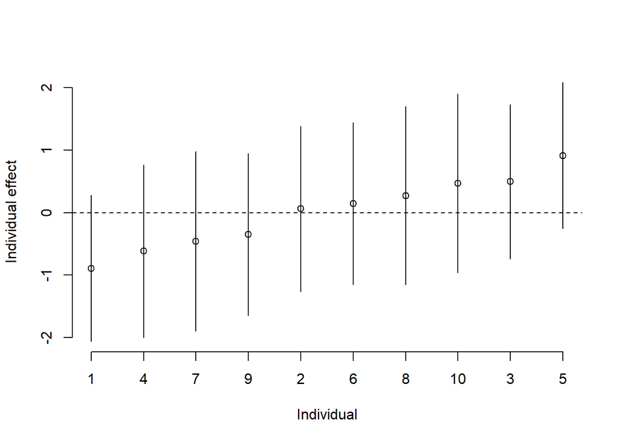

```r
# Now, plot the Individual random effect for the end order of Set1
ci_Set1_End <- CLMM2_End_S1_min$ranef + qnorm(0.975) * sqrt(CLMM2_End_S1_min$condVar) %o% c(-1, 1)
ord.re_Set1_End <- order(CLMM2_End_S1_min$ranef)
ci_Set1_End <- ci_Set1_End[order(CLMM2_End_S1_min$ranef), ]
plot(1:10, CLMM2_End_S1_min$ranef[ord.re_Set1_End], axes = FALSE, ylim = range(ci_Set1_End),
     xlab = "Individual", ylab = "Individual effect")
axis(1, at = 1:10, labels = ord.re_Set1_End)
axis(2)
for(i in 1:10) segments(i, ci_Set1_End[i, 1], i, ci_Set1_End[i, 2])
abline(h = 0, lty = 2)
```

# C - Analysis of leadership using CLMMs in Set2

This set focuses on trios of female mallards with identical rewards but different spatial information on where to find the rewards.

## 1. Analysis of the entrance order in the maze

```r
Set2 <- Set2 %>%
  group_by(OrderAll) %>%
  mutate(PrD_Mob_av = mean(Mobility),
         PrD_Exp_av = mean(Explored_Surface),
         PrD_Voc_av = mean(PrD_voca),
         PrD_For_av = mean(PrD_foraging),
         PrD_Emi_av = mean(Att_Emitted),
         PrD_Suf_av = mean(Att_Suffered),
         PrD_Dis_av = mean(DistDoor),
         SMI_av = mean(SMI),
         Exp_av = mean(Exploration),
         LTi_av = mean(LearningTime),
         FNN_av = mean(FreqNN),
         NPa_av = mean(NumPas),
         PrD_Mob_rel = Mobility - PrD_Mob_av,
         PrD_Exp_rel = Explored_Surface - PrD_Exp_av,
         PrD_Voc_rel = PrD_voca - PrD_Voc_av,
         PrD_For_rel = PrD_foraging - PrD_For_av,
         PrD_Emi_rel = Att_Emitted - PrD_Emi_av,
         PrD_Suf_rel = Att_Suffered - PrD_Suf_av,
         PrD_Dis_rel = DistDoor - PrD_Dis_av,
         SMI_rel = SMI - SMI_av,
         Exp_rel = Exploration - Exp_av,
         LTi_rel = LearningTime - LTi_av,
         FNN_rel = FreqNN - FNN_av,
         NPa_rel = NumPas - NPa_av)

Set2$PrD_Mob_rel_s <- as.numeric(scale(Set2$PrD_Mob_rel))
Set2$PrD_Exp_rel_s <- as.numeric(scale(Set2$PrD_Exp_rel))
Set2$PrD_Voc_rel_s <- as.numeric(scale(Set2$PrD_Voc_rel))
Set2$PrD_For_rel_s <- as.numeric(scale(Set2$PrD_For_rel))
Set2$PrD_Emi_rel_s <- as.numeric(scale(Set2$PrD_Emi_rel))
Set2$PrD_Suf_rel_s <- as.numeric(scale(Set2$PrD_Suf_rel))
Set2$PrD_Dis_rel_s <- as.numeric(scale(Set2$PrD_Dis_rel))
Set2$SMI_rel_s <- as.numeric(scale(Set2$SMI_rel))
Set2$Exp_rel_s <- as.numeric(scale(Set2$Exp_rel))
Set2$LTi_rel_s <- as.numeric(scale(Set2$LTi_rel))
Set2$FNN_rel_s <- as.numeric(scale(Set2$FNN_rel))
Set2$NPa_rel_s <- as.numeric(scale(Set2$NPa_rel))

##Entrance Order
# Null CLMM
CLMM_Entrance_S2_Null <- clmm(OrderEntrance ~ 1 +
                            (1|OrderAll) + (1|Individual), data = Set2)
summary(CLMM_Entrance_S2_Null)
```

```
## Cumulative Link Mixed Model fitted with the Laplace approximation
##
## formula: OrderEntrance ~ 1 + (1 | OrderAll) + (1 | Individual)
## data:    Set2
##
##  link  threshold nobs logLik AIC    niter    max.grad cond.H
##  logit flexible  75   -75.86 159.72 102(309) 2.70e-06 8.1e+00
##
## Random effects:
##  Groups     Name        Variance  Std.Dev.
##  OrderAll   (Intercept) 1.611e-13 4.013e-07
##  Individual (Intercept) 1.645e+00 1.283e+00
## Number of groups:  OrderAll 25,  Individual 10
##
## No Coefficients
##
## Threshold coefficients:
##     Estimate Std. Error z value
## 1|2  -0.8964     0.4991  -1.796
## 2|3   0.9853     0.5033   1.958
## (15 observations deleted due to missingness)
```

```r
# Full CLMM
CLMM_Entrance_S2_Full <- clmm(OrderEntrance ~ PrD_Mob_rel_s + PrD_Exp_rel_s + PrD_Voc_rel_s + PrD_For_rel_s + PrD_Emi_rel_s +
                                PrD_Suf_rel_s + PrD_Dis_rel_s + SMI_rel_s + Exp_rel_s + LTi_rel_s + FNN_rel_s + NPa_rel_s +
                                Side + MajMin +
                                (1|OrderAll) + (1|Individual), data = Set2)
summary(CLMM_Entrance_S2_Full)
```

```
## Cumulative Link Mixed Model fitted with the Laplace approximation
##
## formula: OrderEntrance ~ PrD_Mob_rel_s + PrD_Exp_rel_s + PrD_Voc_rel_s +
##     PrD_For_rel_s + PrD_Emi_rel_s + PrD_Suf_rel_s + PrD_Dis_rel_s +
##     SMI_rel_s + Exp_rel_s + LTi_rel_s + FNN_rel_s + NPa_rel_s +
##     Side + MajMin + (1 | OrderAll) + (1 | Individual)
## data:    Set2
##
##  link  threshold nobs logLik AIC    niter      max.grad cond.H
##  logit flexible  75   -60.69 157.37 1543(1165) 1.23e-04 1.8e+02
##
## Random effects:
##  Groups     Name        Variance Std.Dev.
##  OrderAll   (Intercept) 0        0
##  Individual (Intercept) 0        0
## Number of groups:  OrderAll 25,  Individual 10
##
## Coefficients:
##               Estimate Std. Error z value Pr(>|z|)
## PrD_Mob_rel_s  -0.6831     0.6760  -1.010  0.31226
## PrD_Exp_rel_s   0.1873     0.3596   0.521  0.60240
## PrD_Voc_rel_s   0.3452     0.5844   0.591  0.55481
## PrD_For_rel_s  -0.6237     0.3555  -1.754  0.07936 .
## PrD_Emi_rel_s   0.5160     0.4181   1.234  0.21713
## PrD_Suf_rel_s   0.8576     0.4780   1.794  0.07275 .
## PrD_Dis_rel_s   0.9861     0.3381   2.917  0.00353 **
## SMI_rel_s      -1.3330     0.7085  -1.881  0.05991 .
## Exp_rel_s       0.1679     0.4590   0.366  0.71460
## LTi_rel_s      -1.4814     0.4900  -3.023  0.00250 **
## FNN_rel_s       0.5156     0.3446   1.496  0.13466
## NPa_rel_s       0.0114     0.2786   0.041  0.96737
## SideG          -0.0139     1.1841  -0.012  0.99063
## MajMin          0.2772     0.6208   0.446  0.65530
## ---
## Signif. codes:  0 '***' 0.001 '**' 0.01 '*' 0.05 '.' 0.1 ' ' 1
##
## Threshold coefficients:
##     Estimate Std. Error z value
## 1|2  -0.8959     0.7684  -1.166
## 2|3   1.2856     0.7857   1.636
## (15 observations deleted due to missingness)
```

```r
# backward elimination of non-significant term, only the first step and the minimal model are shown here
CLMM_Entrance_S2_Full_drop <- drop1(CLMM_Entrance_S2_Full)
```

[output not shown]

```r
CLMM_Entrance_S2_Full_drop[CLMM_Entrance_S2_Full_drop$AIC == min(CLMM_Entrance_S2_Full_drop$AIC), ]
```

```
## Single term deletions
##
## Model:
## OrderEntrance ~ PrD_Mob_rel_s + PrD_Exp_rel_s + PrD_Voc_rel_s +
##     PrD_For_rel_s + PrD_Emi_rel_s + PrD_Suf_rel_s + PrD_Dis_rel_s +
##     SMI_rel_s + Exp_rel_s + LTi_rel_s + FNN_rel_s + NPa_rel_s +
##     Side + MajMin + (1 | OrderAll) + (1 | Individual)
##      Df    AIC
## Side  1 155.37
```

```r
CLMM_Entrance_S2_min <- clmm(OrderEntrance ~ PrD_Dis_rel_s + SMI_rel_s + LTi_rel_s +
                                (1|OrderAll) + (1|Individual), data = Set2)
summary(CLMM_Entrance_S2_min)
```

```
## Cumulative Link Mixed Model fitted with the Laplace approximation
##
## formula: OrderEntrance ~ PrD_Dis_rel_s + SMI_rel_s + LTi_rel_s + (1 |
##     OrderAll) + (1 | Individual)
## data:    Set2
##
##  link  threshold nobs logLik AIC    niter    max.grad cond.H
##  logit flexible  75   -65.50 144.99 287(584) 1.45e-04 4.3e+00
##
## Random effects:
##  Groups     Name        Variance Std.Dev.
##  OrderAll   (Intercept) 0.0000   0.0000
##  Individual (Intercept) 0.2045   0.4522
## Number of groups:  OrderAll 25,  Individual 10
##
## Coefficients:
##               Estimate Std. Error z value Pr(>|z|)
## PrD_Dis_rel_s   0.6155     0.2626   2.344 0.019101 *
## SMI_rel_s      -1.0224     0.3046  -3.356 0.000790 ***
## LTi_rel_s      -1.2055     0.3249  -3.710 0.000207 ***
## ---
## Signif. codes:  0 '***' 0.001 '**' 0.01 '*' 0.05 '.' 0.1 ' ' 1
##
## Threshold coefficients:
##     Estimate Std. Error z value
## 1|2  -1.0298     0.3430  -3.002
## 2|3   1.0539     0.3447   3.058
## (15 observations deleted due to missingness)
```

```r
# in order to obtain predicted values, switch to clmm2()
CLMM2_Entrance_S2_min <- clmm2(OrderEntrance ~ PrD_Dis_rel_s + SMI_rel_s + LTi_rel_s,
                               random = Individual, Hess = TRUE, data = Set2)
summary(CLMM2_Entrance_S2_min)
```

```
## Cumulative Link Mixed Model fitted with the Laplace approximation
##
## Call:
## clmm2(location = OrderEntrance ~ PrD_Dis_rel_s + SMI_rel_s +
##     LTi_rel_s, random = Individual, data = Set2, Hess = TRUE)
##
## Random effects:
##                  Var  Std.Dev
## Individual 0.2041359 0.451814
##
## Location coefficients:
##               Estimate Std. Error z value Pr(>|z|)
## PrD_Dis_rel_s  0.6155   0.2626     2.3438 0.01909071
## SMI_rel_s     -1.0223   0.3045    -3.3570 0.00078779
## LTi_rel_s     -1.2054   0.3248    -3.7109 0.00020649
##
## No scale coefficients
##
## Threshold coefficients:
##     Estimate Std. Error z value
## 1|2 -1.0298   0.3430    -3.0027
## 2|3  1.0538   0.3446     3.0583
##
## log-likelihood: -65.49654
## AIC: 142.9931
## Condition number of Hessian: 17.45368
## (15 observations deleted due to missingness)
```

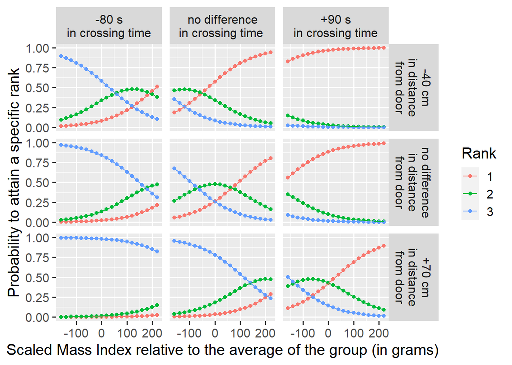

```r
# New data for Set2
newdata_Set2_Entrance <- expand.grid(PrD_Dis_rel = seq(from = -40,
                                                       to = 70,
                                                       by = 10),
                                     SMI_rel = seq(from = -160,
                                                     to = 220,
                                                     by = 20),
                                     LTi_rel = seq(from = -80,
                                                     to = 90,
                                                     by = 10))

# the next three lines enable to report the data on the scaled units
newdata_Set2_Entrance$PrD_Dis_rel_s <- (newdata_Set2_Entrance$PrD_Dis_rel - mean(Set2$PrD_Dis_rel, na.rm = TRUE)) / sd(Set2$PrD_Dis_rel, na.rm = TRUE)
newdata_Set2_Entrance$SMI_rel_s <- (newdata_Set2_Entrance$SMI_rel - mean(Set2$SMI_rel)) / sd(Set2$SMI_rel)
newdata_Set2_Entrance$LTi_rel_s <- (newdata_Set2_Entrance$LTi_rel - mean(Set2$LTi_rel)) / sd(Set2$LTi_rel)


# Predict values for Set2
predict_Set2_Entrance <- sapply(as.character(1:3),
                       function(x) {
                         newdata1 = expand.grid(PrD_Dis_rel_s = seq(from = min(newdata_Set2_Entrance$PrD_Dis_rel_s),
                                                                    to = max(newdata_Set2_Entrance$PrD_Dis_rel_s),
                                                                    by = (10 - mean(Set2$PrD_Dis_rel, na.rm = TRUE)) / sd(Set2$PrD_Dis_rel, na.rm = TRUE)),
                                                SMI_rel_s = seq(from = min(newdata_Set2_Entrance$SMI_rel_s),
                                                                    to = max(newdata_Set2_Entrance$SMI_rel_s),
                                                                    by = (20 - mean(Set2$SMI_rel)) / sd(Set2$SMI_rel)),
                                                LTi_rel_s = seq(from = min(newdata_Set2_Entrance$LTi_rel_s),
                                                                    to = max(newdata_Set2_Entrance$LTi_rel_s),
                                                                    by = (10 - mean(Set2$LTi_rel)) / sd(Set2$LTi_rel)),
                                                OrderEntrance = factor(x, levels = levels(Set2$OrderEntrance)))
                         predict(CLMM2_Entrance_S2_min, newdata = newdata1) })

# bind together the new data and the predicted values
predict_Set2_Entrance <- cbind(newdata_Set2_Entrance, predict_Set2_Entrance)

# pass the dataframe in a long format
predict_Set2_Entrance <- predict_Set2_Entrance %>%
  gather("1", "2", "3", key = "Rank", value = "prob")


# produce the graph
predict_Set2_Entrancebis <- predict_Set2_Entrance %>%
  filter((LTi_rel == min(LTi_rel) |
           LTi_rel == 0 |
           LTi_rel == max(LTi_rel)) &
           (PrD_Dis_rel == min(PrD_Dis_rel) |
           PrD_Dis_rel == 0 |
           PrD_Dis_rel == max(PrD_Dis_rel)))

LTi_rel.labs <- c("-80 s\nin crossing time", "no difference\nin crossing time ", "+90 s\nin crossing time")
names(LTi_rel.labs) <- c("-80", "0", "90")

PrD_Dis_rel.labs <- c("-40 cm\nin distance\nfrom door", "no difference\nin distance\nfrom door", "+70 cm\nin distance\nfrom door")
names(PrD_Dis_rel.labs) <- c("-40", "0", "70")

predict_Set2_Entrancebis %>%
  ggplot(aes(x = SMI_rel, y = prob, colour = Rank)) +
  geom_point() +
  geom_line() +
  facet_grid(PrD_Dis_rel ~ LTi_rel, labeller = labeller(LTi_rel = LTi_rel.labs, PrD_Dis_rel = PrD_Dis_rel.labs)) +
  labs(x = "Scaled Mass Index relative to the average of the group (in grams)",
       y = "Probability to attain a specific rank") +
  theme_gray(base_size = 15)
```

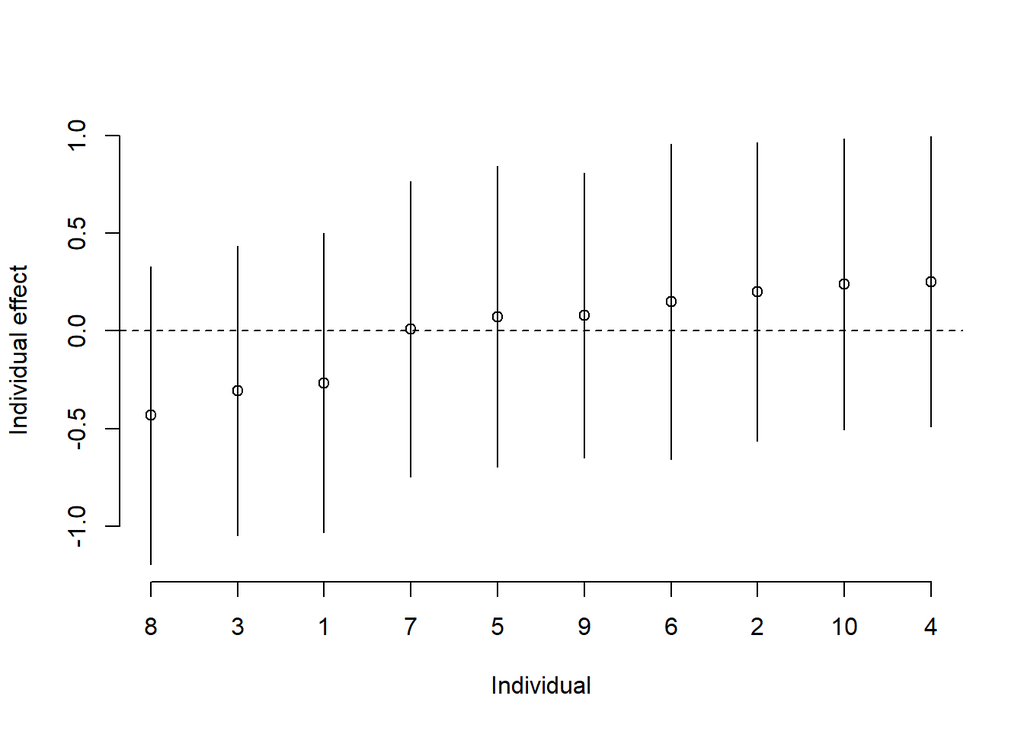

```r
# random effect for Set2 Entrance order
ci_Set2_Entrance <- CLMM2_Entrance_S2_min$ranef + qnorm(0.975) * sqrt(CLMM2_Entrance_S2_min$condVar) %o% c(-1, 1)
ord.re_Set2_Entrance <- order(CLMM2_Entrance_S2_min$ranef)
ci_Set2_Entrance <- ci_Set2_Entrance[order(CLMM2_Entrance_S2_min$ranef), ]
plot(1:10, CLMM2_Entrance_S2_min$ranef[ord.re_Set2_Entrance], axes = FALSE, ylim = range(ci_Set2_Entrance),
     xlab = "Individual", ylab = "Individual effect")
axis(1, at = 1:10, labels = ord.re_Set2_Entrance)
axis(2)
for(i in 1:10) segments(i, ci_Set2_Entrance[i, 1], i, ci_Set2_Entrance[i, 2])
abline(h = 0, lty = 2)
```

```r
Set2_nf <- Set2_nf %>%
  group_by(OrderAll) %>%
  mutate(PrD_Mob_av = mean(Mobility),
         PrD_Exp_av = mean(Explored_Surface),
         PrD_Voc_av = mean(PrD_voca),
         PrD_For_av = mean(PrD_foraging),
         PrD_Emi_av = mean(Att_Emitted),
         PrD_Suf_av = mean(Att_Suffered),
         PrD_Dis_av = mean(DistDoor),
         SMI_av = mean(SMI),
         Exp_av = mean(Exploration),
         LTi_av = mean(LearningTime),
         FNN_av = mean(FreqNN),
         NPa_av = mean(NumPas),
         PrD_Mob_rel = Mobility - PrD_Mob_av,
         PrD_Exp_rel = Explored_Surface - PrD_Exp_av,
         PrD_Voc_rel = PrD_voca - PrD_Voc_av,
         PrD_For_rel = PrD_foraging - PrD_For_av,
         PrD_Emi_rel = Att_Emitted - PrD_Emi_av,
         PrD_Suf_rel = Att_Suffered - PrD_Suf_av,
         PrD_Dis_rel = DistDoor - PrD_Dis_av,
         SMI_rel = SMI - SMI_av,
         Exp_rel = Exploration - Exp_av,
         LTi_rel = LearningTime - LTi_av,
         FNN_rel = FreqNN - FNN_av,
         NPa_rel = NumPas - NPa_av)

Set2_nf$PrD_Mob_rel_s <- as.numeric(scale(Set2_nf$PrD_Mob_rel))
Set2_nf$PrD_Exp_rel_s <- as.numeric(scale(Set2_nf$PrD_Exp_rel))
Set2_nf$PrD_Voc_rel_s <- as.numeric(scale(Set2_nf$PrD_Voc_rel))
Set2_nf$PrD_For_rel_s <- as.numeric(scale(Set2_nf$PrD_For_rel))
Set2_nf$PrD_Emi_rel_s <- as.numeric(scale(Set2_nf$PrD_Emi_rel))
Set2_nf$PrD_Suf_rel_s <- as.numeric(scale(Set2_nf$PrD_Suf_rel))
Set2_nf$PrD_Dis_rel_s <- as.numeric(scale(Set2_nf$PrD_Dis_rel))
Set2_nf$SMI_rel_s <- as.numeric(scale(Set2_nf$SMI_rel))
Set2_nf$Exp_rel_s <- as.numeric(scale(Set2_nf$Exp_rel))
Set2_nf$LTi_rel_s <- as.numeric(scale(Set2_nf$LTi_rel))
Set2_nf$FNN_rel_s <- as.numeric(scale(Set2_nf$FNN_rel))
Set2_nf$NPa_rel_s <- as.numeric(scale(Set2_nf$NPa_rel))

##End Order
# Null CLMM
CLMM_End_S2_Null <- clmm(OrderEnd ~ 1 +
                            (1|OrderAll) + (1|Individual), data = Set2_nf)
summary(CLMM_End_S2_Null)
```

```
## Cumulative Link Mixed Model fitted with the Laplace approximation
##
## formula: OrderEnd ~ 1 + (1 | OrderAll) + (1 | Individual)
## data:    Set2_nf
##
##  link  threshold nobs logLik AIC    niter   max.grad cond.H
##  logit flexible  90   -87.26 182.51 94(291) 1.03e-06 1.1e+01
##
## Random effects:
##  Groups     Name        Variance  Std.Dev.
##  OrderAll   (Intercept) 6.518e-16 2.553e-08
##  Individual (Intercept) 2.532e+00 1.591e+00
## Number of groups:  OrderAll 30,  Individual 10
##
## No Coefficients
##
## Threshold coefficients:
##     Estimate Std. Error z value
## 1|2  -0.9383     0.5792  -1.620
## 2|3   1.0818     0.5805   1.864
```

```r
# Full CLMM
CLMM_End_S2_Full <- clmm(OrderEnd ~ PrD_Mob_rel_s + PrD_Exp_rel_s + PrD_Voc_rel_s + PrD_For_rel_s + PrD_Emi_rel_s +
                                PrD_Suf_rel_s + PrD_Dis_rel_s + SMI_rel_s + Exp_rel_s + LTi_rel_s + FNN_rel_s + NPa_rel_s +
                                Side + MajMin +
                                (1|OrderAll) + (1|Individual), data = Set2_nf)
summary(CLMM_End_S2_Full)
```

```
## Cumulative Link Mixed Model fitted with the Laplace approximation
##
## formula:
## OrderEnd ~ PrD_Mob_rel_s + PrD_Exp_rel_s + PrD_Voc_rel_s + PrD_For_rel_s +
##     PrD_Emi_rel_s + PrD_Suf_rel_s + PrD_Dis_rel_s + SMI_rel_s +
##     Exp_rel_s + LTi_rel_s + FNN_rel_s + NPa_rel_s + Side + MajMin +
##     (1 | OrderAll) + (1 | Individual)
## data:    Set2_nf
##
##  link  threshold nobs logLik AIC    niter      max.grad cond.H
##  logit flexible  75   -49.48 134.97 1380(2801) 3.28e-05 1.9e+02
##
## Random effects:
##  Groups     Name        Variance Std.Dev.
##  OrderAll   (Intercept) 0.0000   0.0000
##  Individual (Intercept) 0.4849   0.6964
## Number of groups:  OrderAll 25,  Individual 10
##
## Coefficients:
##               Estimate Std. Error z value Pr(>|z|)
## PrD_Mob_rel_s   1.3284     0.8474   1.568   0.1170
## PrD_Exp_rel_s  -0.2305     0.4255  -0.542   0.5880
## PrD_Voc_rel_s  -1.0112     0.7287  -1.388   0.1652
## PrD_For_rel_s  -0.7188     0.4513  -1.593   0.1112
## PrD_Emi_rel_s  -0.3871     0.4844  -0.799   0.4243
## PrD_Suf_rel_s  -0.6252     0.5662  -1.104   0.2695
## PrD_Dis_rel_s   0.1599     0.3481   0.460   0.6459
## SMI_rel_s      -2.1614     1.0325  -2.093   0.0363 *
## Exp_rel_s       1.2972     0.7235   1.793   0.0730 .
## LTi_rel_s      -0.7494     0.6488  -1.155   0.2481
## FNN_rel_s       2.3422     0.5962   3.928 8.56e-05 ***
## NPa_rel_s       0.6103     0.3300   1.849   0.0644 .
## SideG           2.1551     1.6245   1.327   0.1846
## MajMin         -0.7692     0.7328  -1.050   0.2938
## ---
## Signif. codes:  0 '***' 0.001 '**' 0.01 '*' 0.05 '.' 0.1 ' ' 1
##
## Threshold coefficients:
##     Estimate Std. Error z value
## 1|2  -0.8786     1.1600  -0.757
## 2|3   2.2758     1.0643   2.138
## (15 observations deleted due to missingness)
```

```r
# backward elimination of non-significant term, only the first step and the minimal model are shown here
CLMM_End_S2_Full_drop <- drop1(CLMM_End_S2_Full)
```

[output not shown]

```r
CLMM_End_S2_Full_drop[CLMM_End_S2_Full_drop$AIC == min(CLMM_End_S2_Full_drop$AIC), ]
```

```
## Single term deletions
##
## Model:
## OrderEnd ~ PrD_Mob_rel_s + PrD_Exp_rel_s + PrD_Voc_rel_s + PrD_For_rel_s +
##     PrD_Emi_rel_s + PrD_Suf_rel_s + PrD_Dis_rel_s + SMI_rel_s +
##     Exp_rel_s + LTi_rel_s + FNN_rel_s + NPa_rel_s + Side + MajMin +
##     (1 | OrderAll) + (1 | Individual)
##               Df    AIC
## PrD_Dis_rel_s  1 133.18
```

```r
CLMM_End_S2_min <- clmm(OrderEnd ~ FNN_rel_s +
                          (1|OrderAll) + (1|Individual), data = Set2_nf)
summary(CLMM_End_S2_min)
```

```
## Cumulative Link Mixed Model fitted with the Laplace approximation
##
## formula: OrderEnd ~ FNN_rel_s + (1 | OrderAll) + (1 | Individual)
## data:    Set2_nf
##
##  link  threshold nobs logLik AIC    niter    max.grad cond.H
##  logit flexible  90   -78.22 166.43 133(402) 4.23e-05 5.3e+00
##
## Random effects:
##  Groups     Name        Variance  Std.Dev.
##  OrderAll   (Intercept) 4.618e-11 6.795e-06
##  Individual (Intercept) 9.903e-01 9.951e-01
## Number of groups:  OrderAll 30,  Individual 10
##
## Coefficients:
##           Estimate Std. Error z value Pr(>|z|)
## FNN_rel_s   1.5626     0.3842   4.067 4.75e-05 ***
## ---
## Signif. codes:  0 '***' 0.001 '**' 0.01 '*' 0.05 '.' 0.1 ' ' 1
##
## Threshold coefficients:
##     Estimate Std. Error z value
## 1|2  -1.0420     0.4371  -2.384
## 2|3   1.1924     0.4350   2.741
```

```r
# in order to obtain predicted values, switch to clmm2()
CLMM2_End_S2_min <- clmm2(OrderEnd ~ FNN_rel_s,
                               random = Individual, Hess = TRUE, data = Set2_nf)
summary(CLMM2_End_S2_min)
```

```
## Cumulative Link Mixed Model fitted with the Laplace approximation
##
## Call:
## clmm2(location = OrderEnd ~ FNN_rel_s, random = Individual, data = Set2_nf,
##     Hess = TRUE)
##
## Random effects:
##                  Var   Std.Dev
## Individual 0.9880973 0.9940308
##
## Location coefficients:
##           Estimate Std. Error z value Pr(>|z|)
## FNN_rel_s  1.5624   0.3840     4.0684 4.7342e-05
##
## No scale coefficients
##
## Threshold coefficients:
##     Estimate Std. Error z value
## 1|2 -1.0418   0.4368    -2.3850
## 2|3  1.1923   0.4348     2.7424
##
## log-likelihood: -78.21655
## AIC: 164.4331
## Condition number of Hessian: 5.319765
```

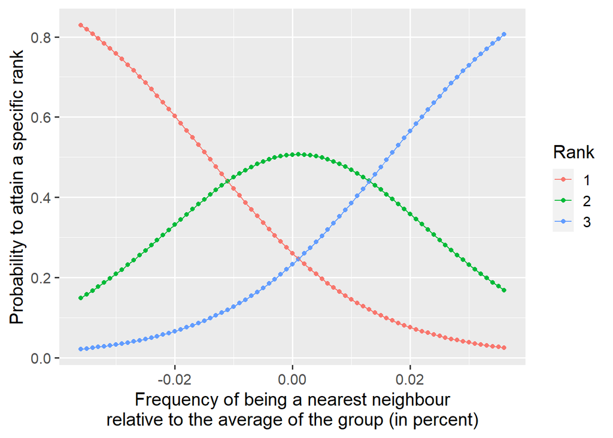

```r
# New data for Set2
newdata_Set2_End <- expand.grid(FNN_rel = seq(from = -0.036,
                                              to = 0.036,
                                              by = 0.001))

# the next line enables to report the data on the scaled units
newdata_Set2_End$FNN_rel_s <- (newdata_Set2_End$FNN_rel - mean(Set2_nf$FNN_rel)) / sd(Set2_nf$FNN_rel)

predict_Set2_End <- sapply(as.character(1:3),
                            function(x) {
                              newdata1 = expand.grid(FNN_rel_s = seq(from = min(newdata_Set2_End$FNN_rel_s),
                                                                     to = max(newdata_Set2_End$FNN_rel_s),
                                                                     by =  (0.001 - mean(Set2_nf$FNN_rel)) / sd(Set2_nf$FNN_rel)),
                                                     OrderEnd = factor(x, levels = levels(Set2_nf$OrderEnd)))
                              predict(CLMM2_End_S2_min, newdata = newdata1) })

# bind together the new data and the predicted values
predict_Set2_End <- cbind(newdata_Set2_End, predict_Set2_End)

# pass the dataframe in a long format
predict_Set2_End <- predict_Set2_End %>%
  gather("1", "2", "3", key = "Rank", value = "prob")


predict_Set2_End %>%
  ggplot(aes(x = FNN_rel, y = prob, colour = Rank)) +
  geom_point() +
  geom_line() +
  labs(x = "Frequency of being a nearest neighbour\nrelative to the average of the group (in percent)",
       y = "Probability to attain a specific rank") +
  theme_gray(base_size = 15)
```

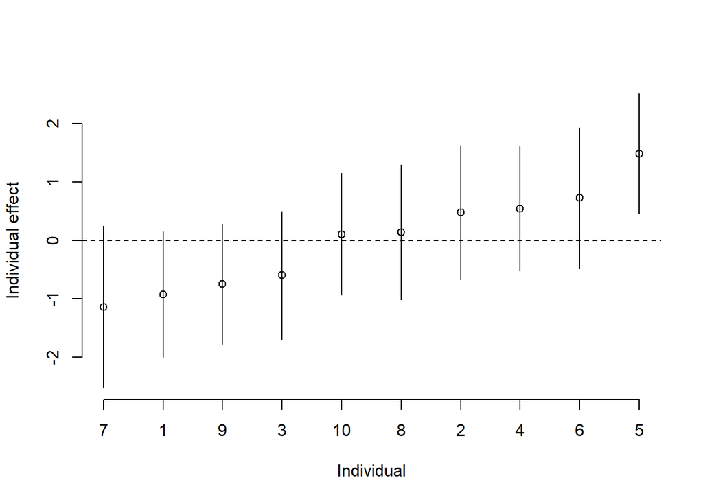

```r
# random effect for Set2 End order
ci_Set2_End <- CLMM2_End_S2_min$ranef + qnorm(0.975) * sqrt(CLMM2_End_S2_min$condVar) %o% c(-1, 1)
ord.re_Set2_End <- order(CLMM2_End_S2_min$ranef)
ci_Set2_End <- ci_Set2_End[order(CLMM2_End_S2_min$ranef), ]
plot(1:10, CLMM2_End_S2_min$ranef[ord.re_Set2_End], axes = FALSE, ylim = range(ci_Set2_End),
     xlab = "Individual", ylab = "Individual effect")
axis(1, at = 1:10, labels = ord.re_Set2_End)
axis(2)
for(i in 1:10) segments(i, ci_Set2_End[i, 1], i, ci_Set2_End[i, 2])
abline(h = 0, lty = 2)
```

# D - Analysis of leadership using CLMMs in Set3

This set focuses on trios of female mallards with different rewards and different spatial information on where to find the rewards.

## 1. Analysis of the entrance order in the maze

```r
Set3 <- Set3 %>%
  group_by(OrderAll) %>%
  mutate(PrD_Mob_av = mean(Mobility),
         PrD_Exp_av = mean(Explored_Surface),
         PrD_Voc_av = mean(PrD_voca),
         PrD_For_av = mean(PrD_foraging),
         PrD_Emi_av = mean(Att_Emitted),
         PrD_Suf_av = mean(Att_Suffered),
         PrD_Dis_av = mean(DistDoor),
         SMI_av = mean(SMI),
         Exp_av = mean(Exploration),
         LTi_av = mean(LearningTime),
         FNN_av = mean(FreqNN),
         NPa_av = mean(NumPas),
         PrD_Mob_rel = Mobility - PrD_Mob_av,
         PrD_Exp_rel = Explored_Surface - PrD_Exp_av,
         PrD_Voc_rel = PrD_voca - PrD_Voc_av,
         PrD_For_rel = PrD_foraging - PrD_For_av,
         PrD_Emi_rel = Att_Emitted - PrD_Emi_av,
         PrD_Suf_rel = Att_Suffered - PrD_Suf_av,
         PrD_Dis_rel = DistDoor - PrD_Dis_av,
         SMI_rel = SMI - SMI_av,
         Exp_rel = Exploration - Exp_av,
         LTi_rel = LearningTime - LTi_av,
         FNN_rel = FreqNN - FNN_av,
         NPa_rel = NumPas - NPa_av)

Set3$PrD_Mob_rel_s <- as.numeric(scale(Set3$PrD_Mob_rel))
Set3$PrD_Exp_rel_s <- as.numeric(scale(Set3$PrD_Exp_rel))
Set3$PrD_Voc_rel_s <- as.numeric(scale(Set3$PrD_Voc_rel))
Set3$PrD_For_rel_s <- as.numeric(scale(Set3$PrD_For_rel))
Set3$PrD_Emi_rel_s <- as.numeric(scale(Set3$PrD_Emi_rel))
Set3$PrD_Suf_rel_s <- as.numeric(scale(Set3$PrD_Suf_rel))
Set3$PrD_Dis_rel_s <- as.numeric(scale(Set3$PrD_Dis_rel))
Set3$SMI_rel_s <- as.numeric(scale(Set3$SMI_rel))
Set3$Exp_rel_s <- as.numeric(scale(Set3$Exp_rel))
Set3$LTi_rel_s <- as.numeric(scale(Set3$LTi_rel))
Set3$FNN_rel_s <- as.numeric(scale(Set3$FNN_rel))
Set3$NPa_rel_s <- as.numeric(scale(Set3$NPa_rel))

##Entrance Order
# Null CLMM
CLMM_Entrance_S3_Null <- clmm(OrderEntrance ~ 1 +
                            (1|OrderAll) + (1|Individual), data = Set3)
summary(CLMM_Entrance_S3_Null)
```

```
## Cumulative Link Mixed Model fitted with the Laplace approximation
##
## formula: OrderEntrance ~ 1 + (1 | OrderAll) + (1 | Individual)
## data:    Set3
##
##  link  threshold nobs logLik  AIC    niter   max.grad cond.H
##  logit flexible  126  -125.51 259.02 92(279) 3.01e-05 1.2e+01
##
## Random effects:
##  Groups     Name        Variance Std.Dev.
##  OrderAll   (Intercept) 0.000    0.000
##  Individual (Intercept) 1.636    1.279
## Number of groups:  OrderAll 42,  Individual 10
##
## No Coefficients
##
## Threshold coefficients:
##     Estimate Std. Error z value
## 1|2  -0.7892     0.4600  -1.716
## 2|3   1.0582     0.4672   2.265
```

```r
# Full CLMM
CLMM_Entrance_S3_Full <- clmm(OrderEntrance ~ PrD_Mob_rel_s + PrD_Exp_rel_s + PrD_Voc_rel_s + PrD_For_rel_s + PrD_Emi_rel_s +
                                PrD_Suf_rel_s + PrD_Dis_rel_s + SMI_rel_s + Exp_rel_s + LTi_rel_s + FNN_rel_s + NPa_rel_s +
                                Side + MajMin + Mot +
                                (1|OrderAll) + (1|Individual), data = Set3)
summary(CLMM_Entrance_S3_Full)
```

```
## Cumulative Link Mixed Model fitted with the Laplace approximation
##
## formula: OrderEntrance ~ PrD_Mob_rel_s + PrD_Exp_rel_s + PrD_Voc_rel_s +
##     PrD_For_rel_s + PrD_Emi_rel_s + PrD_Suf_rel_s + PrD_Dis_rel_s +
##     SMI_rel_s + Exp_rel_s + LTi_rel_s + FNN_rel_s + NPa_rel_s +
##     Side + MajMin + Mot + (1 | OrderAll) + (1 | Individual)
## data:    Set3
##
##  link  threshold nobs logLik  AIC    niter      max.grad cond.H
##  logit flexible  126  -110.01 258.03 2207(4497) 1.22e-04 1.6e+02
##
## Random effects:
##  Groups     Name        Variance  Std.Dev.
##  OrderAll   (Intercept) 2.199e-12 1.483e-06
##  Individual (Intercept) 1.473e-01 3.837e-01
## Number of groups:  OrderAll 42,  Individual 10
##
## Coefficients:
##                Estimate Std. Error z value Pr(>|z|)
## PrD_Mob_rel_s  0.221140   0.351244   0.630   0.5290
## PrD_Exp_rel_s -0.192171   0.302108  -0.636   0.5247
## PrD_Voc_rel_s -0.181814   0.260451  -0.698   0.4851
## PrD_For_rel_s -0.115287   0.227806  -0.506   0.6128
## PrD_Emi_rel_s  0.237507   0.217326   1.093   0.2745
## PrD_Suf_rel_s  0.292235   0.224197   1.303   0.1924
## PrD_Dis_rel_s -0.126740   0.209251  -0.606   0.5447
## SMI_rel_s     -1.468733   0.614750  -2.389   0.0169 *
## Exp_rel_s      0.598551   0.462170   1.295   0.1953
## LTi_rel_s     -0.216682   0.359412  -0.603   0.5466
## FNN_rel_s      0.001708   0.338034   0.005   0.9960
## NPa_rel_s      0.155342   0.321478   0.483   0.6289
## SideG         -0.200945   1.031727  -0.195   0.8456
## MajMin         0.816289   0.442083   1.846   0.0648 .
## MotL          -0.608839   0.679329  -0.896   0.3701
## ---
## Signif. codes:  0 '***' 0.001 '**' 0.01 '*' 0.05 '.' 0.1 ' ' 1
##
## Threshold coefficients:
##     Estimate Std. Error z value
## 1|2  -0.7601     0.7468  -1.018
## 2|3   1.3033     0.7495   1.739
```

```r
# backward elimination of non-significant term, only the first step and the minimal model are shown here
CLMM_Entrance_S3_Full_drop <- drop1(CLMM_Entrance_S3_Full)
```

[output not shown]

```r
CLMM_Entrance_S3_Full_drop[CLMM_Entrance_S3_Full_drop$AIC == min(CLMM_Entrance_S3_Full_drop$AIC), ]
```

```
## Single term deletions
##
## Model:
## OrderEntrance ~ PrD_Mob_rel_s + PrD_Exp_rel_s + PrD_Voc_rel_s +
##     PrD_For_rel_s + PrD_Emi_rel_s + PrD_Suf_rel_s + PrD_Dis_rel_s +
##     SMI_rel_s + Exp_rel_s + LTi_rel_s + FNN_rel_s + NPa_rel_s +
##     Side + MajMin + Mot + (1 | OrderAll) + (1 | Individual)
##           Df    AIC
## FNN_rel_s  1 256.03
```

```r
CLMM_Entrance_S3_min <- clmm(OrderEntrance ~ SMI_rel_s + Mot +
                                (1|OrderAll) + (1|Individual), data = Set3, na.action = na.omit)
summary(CLMM_Entrance_S3_min)
```

```
## Cumulative Link Mixed Model fitted with the Laplace approximation
##
## formula: OrderEntrance ~ SMI_rel_s + Mot + (1 | OrderAll) + (1 | Individual)
## data:    Set3
##
##  link  threshold nobs logLik  AIC    niter    max.grad cond.H
##  logit flexible  126  -116.66 245.32 198(419) 2.38e-04 1.6e+01
##
## Random effects:
##  Groups     Name        Variance  Std.Dev.
##  OrderAll   (Intercept) 3.379e-12 1.838e-06
##  Individual (Intercept) 2.574e-01 5.073e-01
## Number of groups:  OrderAll 42,  Individual 10
##
## Coefficients:
##           Estimate Std. Error z value Pr(>|z|)
## SMI_rel_s  -1.3034     0.2690  -4.846 1.26e-06 ***
## MotL       -1.0456     0.5104  -2.049   0.0405 *
## ---
## Signif. codes:  0 '***' 0.001 '**' 0.01 '*' 0.05 '.' 0.1 ' ' 1
##
## Threshold coefficients:
##     Estimate Std. Error z value
## 1|2  -1.3738     0.4097  -3.353
## 2|3   0.5556     0.3815   1.456
```

```r
# in order to obtain predicted values, switch to clmm2()
CLMM2_Entrance_S3_min <- clmm2(OrderEntrance ~ SMI_rel_s + Mot,
                               random = Individual, Hess = TRUE, data = Set3)
summary(CLMM2_Entrance_S3_min)
```

```
## Cumulative Link Mixed Model fitted with the Laplace approximation
##
## Call:
## clmm2(location = OrderEntrance ~ SMI_rel_s + Mot, random = Individual,
##     data = Set3, Hess = TRUE)
##
## Random effects:
##                  Var   Std.Dev
## Individual 0.2559037 0.5058693
##
## Location coefficients:
##           Estimate Std. Error z value Pr(>|z|)
## SMI_rel_s -1.3028   0.2685    -4.8528 1.2175e-06
## MotL      -1.0450   0.5094    -2.0512 0.04024713
##
## No scale coefficients
##
## Threshold coefficients:
##     Estimate Std. Error z value
## 1|2 -1.3734   0.4090    -3.3575
## 2|3  0.5558   0.3809     1.4594
##
## log-likelihood: -116.6612
## AIC: 243.3224
## Condition number of Hessian: 15.80904
```

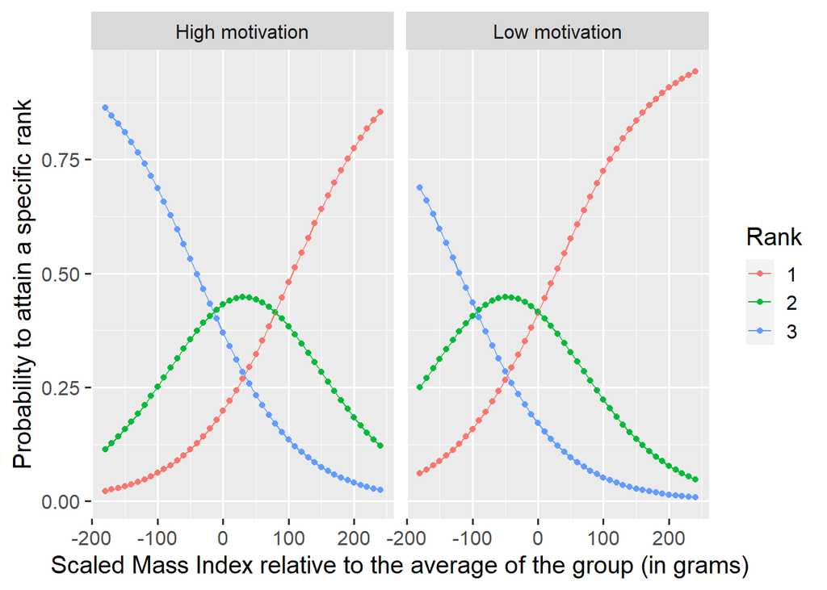

```r
# New data for Set3
newdata_Set3_Entrance <- expand.grid(SMI_rel = seq(from = -180,
                                                     to = 240,
                                                     by = 10),
                                     Mot = c("H", "L"))

# the next two lines enable to report the data on the unscaled units
newdata_Set3_Entrance$SMI_rel_s <- (newdata_Set3_Entrance$SMI_rel - mean(Set3$SMI_rel)) / sd(Set3$SMI_rel)


# Predict values for Set3
predict_Set3_Entrance <- sapply(as.character(1:3),
                       function(x) {
                         newdata1 = expand.grid(SMI_rel_s = seq(from = min(Set3$SMI_rel_s),
                                                                to = max(Set3$SMI_rel_s),
                                                                by = (10 - mean(Set3$SMI_rel)) / sd(Set3$SMI_rel)),
                                                Mot = c("H", "L"),
                                                OrderEntrance = factor(x, levels = levels(Set3$OrderEntrance)))
                         predict(CLMM2_Entrance_S3_min, newdata = newdata1) })

# bind together the new data and the predicted values
predict_Set3_Entrance <- cbind(newdata_Set3_Entrance, predict_Set3_Entrance)

# pass the dataframe in a long format
predict_Set3_Entrance <- predict_Set3_Entrance %>%
  gather("1", "2", "3", key = "Rank", value = "prob")


# produce the graph
Mot.labs <- c("High motivation", "Low motivation")
names(Mot.labs) <- c("H", "L")

predict_Set3_Entrance %>%
  ggplot(aes(x = SMI_rel, y = prob, colour = Rank)) +
  geom_point() +
  geom_line() +
  facet_grid(~ Mot, labeller = labeller(Mot = Mot.labs)) +
  labs(x = "Scaled Mass Index relative to the average of the group (in grams)",
       y = "Probability to attain a specific rank") +
  theme_gray(base_size = 15)
```

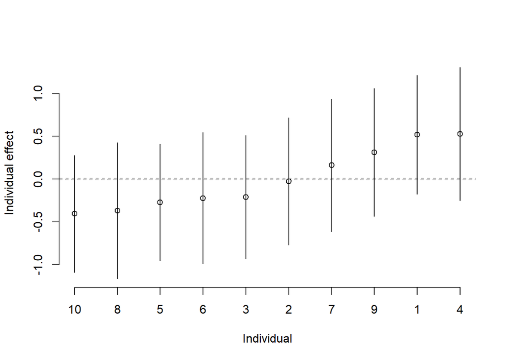

```r
# random effect for Set3 Entrance order
ci_Set3_Entrance <- CLMM2_Entrance_S3_min$ranef + qnorm(0.975) * sqrt(CLMM2_Entrance_S3_min$condVar) %o% c(-1, 1)
ord.re_Set3_Entrance <- order(CLMM2_Entrance_S3_min$ranef)
ci_Set3_Entrance <- ci_Set3_Entrance[order(CLMM2_Entrance_S3_min$ranef), ]
plot(1:10, CLMM2_Entrance_S3_min$ranef[ord.re_Set3_Entrance], axes = FALSE, ylim = range(ci_Set3_Entrance),
     xlab = "Individual", ylab = "Individual effect")
axis(1, at = 1:10, labels = ord.re_Set3_Entrance)
axis(2)
for(i in 1:10) segments(i, ci_Set3_Entrance[i, 1], i, ci_Set3_Entrance[i, 2])
abline(h = 0, lty = 2)
```

## 2. Analysis of the end order in the maze

```r
Set3_nf <- Set3_nf %>%
  group_by(OrderAll) %>%
  mutate(PrD_Mob_av = mean(Mobility),
         PrD_Exp_av = mean(Explored_Surface),
         PrD_Voc_av = mean(PrD_voca),
         PrD_For_av = mean(PrD_foraging),
         PrD_Emi_av = mean(Att_Emitted),
         PrD_Suf_av = mean(Att_Suffered),
         PrD_Dis_av = mean(DistDoor),
         SMI_av = mean(SMI),
         Exp_av = mean(Exploration),
         LTi_av = mean(LearningTime),
         FNN_av = mean(FreqNN),
         NPa_av = mean(NumPas),
         PrD_Mob_rel = Mobility - PrD_Mob_av,
         PrD_Exp_rel = Explored_Surface - PrD_Exp_av,
         PrD_Voc_rel = PrD_voca - PrD_Voc_av,
         PrD_For_rel = PrD_foraging - PrD_For_av,
         PrD_Emi_rel = Att_Emitted - PrD_Emi_av,
         PrD_Suf_rel = Att_Suffered - PrD_Suf_av,
         PrD_Dis_rel = DistDoor - PrD_Dis_av,
         SMI_rel = SMI - SMI_av,
         Exp_rel = Exploration - Exp_av,
         LTi_rel = LearningTime - LTi_av,
         FNN_rel = FreqNN - FNN_av,
         NPa_rel = NumPas - NPa_av)

Set3_nf$PrD_Mob_rel_s <- as.numeric(scale(Set3_nf$PrD_Mob_rel))
Set3_nf$PrD_Exp_rel_s <- as.numeric(scale(Set3_nf$PrD_Exp_rel))
Set3_nf$PrD_Voc_rel_s <- as.numeric(scale(Set3_nf$PrD_Voc_rel))
Set3_nf$PrD_For_rel_s <- as.numeric(scale(Set3_nf$PrD_For_rel))
Set3_nf$PrD_Emi_rel_s <- as.numeric(scale(Set3_nf$PrD_Emi_rel))
Set3_nf$PrD_Suf_rel_s <- as.numeric(scale(Set3_nf$PrD_Suf_rel))
Set3_nf$PrD_Dis_rel_s <- as.numeric(scale(Set3_nf$PrD_Dis_rel))
Set3_nf$SMI_rel_s <- as.numeric(scale(Set3_nf$SMI_rel))
Set3_nf$Exp_rel_s <- as.numeric(scale(Set3_nf$Exp_rel))
Set3_nf$LTi_rel_s <- as.numeric(scale(Set3_nf$LTi_rel))
Set3_nf$FNN_rel_s <- as.numeric(scale(Set3_nf$FNN_rel))
Set3_nf$NPa_rel_s <- as.numeric(scale(Set3_nf$NPa_rel))

##End Order
# Null CLMM
CLMM_End_S3_Null <- clmm(OrderEnd ~ 1 +
                            (1|OrderAll) + (1|Individual), data = Set3_nf)
summary(CLMM_End_S3_Null)
```

```
## Cumulative Link Mixed Model fitted with the Laplace approximation
##
## formula: OrderEnd ~ 1 + (1 | OrderAll) + (1 | Individual)
## data:    Set3_nf
##
##  link  threshold nobs logLik  AIC    niter   max.grad cond.H
##  logit flexible  126  -117.31 242.62 94(291) 1.57e-08 1.8e+01
##
## Random effects:
##  Groups     Name        Variance  Std.Dev.
##  OrderAll   (Intercept) 1.653e-18 1.286e-09
##  Individual (Intercept) 3.175e+00 1.782e+00
## Number of groups:  OrderAll 42,  Individual 10
##
## No Coefficients
##
## Threshold coefficients:
##     Estimate Std. Error z value
## 1|2  -1.0074     0.6178  -1.631
## 2|3   1.0779     0.6163   1.749
```

```r
# Full CLMM
CLMM_End_S3_Full <- clmm(OrderEnd ~ PrD_Mob_rel_s + PrD_Exp_rel_s + PrD_Voc_rel_s + PrD_For_rel_s + PrD_Emi_rel_s +
                                PrD_Suf_rel_s + PrD_Dis_rel_s + SMI_rel_s + Exp_rel_s + LTi_rel_s + FNN_rel_s + NPa_rel_s +
                                Side + MajMin + Mot +
                                (1|OrderAll) + (1|Individual), data = Set3_nf)
summary(CLMM_End_S3_Full)
```

```
## Cumulative Link Mixed Model fitted with the Laplace approximation
##
## formula:
## OrderEnd ~ PrD_Mob_rel_s + PrD_Exp_rel_s + PrD_Voc_rel_s + PrD_For_rel_s +
##     PrD_Emi_rel_s + PrD_Suf_rel_s + PrD_Dis_rel_s + SMI_rel_s +
##     Exp_rel_s + LTi_rel_s + FNN_rel_s + NPa_rel_s + Side + MajMin +
##     Mot + (1 | OrderAll) + (1 | Individual)
## data:    Set3_nf
##
##  link  threshold nobs logLik AIC    niter     max.grad cond.H
##  logit flexible  126  -86.37 210.73 1975(372) 6.49e-05 1.6e+02
##
## Random effects:
##  Groups     Name        Variance  Std.Dev.
##  OrderAll   (Intercept) 1.153e-12 1.074e-06
##  Individual (Intercept) 0.000e+00 0.000e+00
## Number of groups:  OrderAll 42,  Individual 10
##
## Coefficients:
##               Estimate Std. Error z value Pr(>|z|)
## PrD_Mob_rel_s  -0.5620     0.4029  -1.395   0.1631
## PrD_Exp_rel_s   0.6146     0.3400   1.808   0.0707 .
## PrD_Voc_rel_s   0.2629     0.3523   0.746   0.4554
## PrD_For_rel_s  -0.0548     0.2487  -0.220   0.8256
## PrD_Emi_rel_s  -0.4483     0.2273  -1.973   0.0485 *
## PrD_Suf_rel_s   0.4043     0.2427   1.666   0.0957 .
## PrD_Dis_rel_s   0.2901     0.2270   1.278   0.2012
## SMI_rel_s      -1.3244     0.6743  -1.964   0.0495 *
## Exp_rel_s       0.2702     0.5061   0.534   0.5935
## LTi_rel_s       0.4083     0.3824   1.068   0.2856
## FNN_rel_s       2.1870     0.4093   5.343 9.15e-08 ***
## NPa_rel_s       0.2920     0.3364   0.868   0.3854
## SideG           0.4213     1.1038   0.382   0.7027
## MajMin         -0.4812     0.4850  -0.992   0.3211
## MotL           -0.3804     0.6478  -0.587   0.5571
## ---
## Signif. codes:  0 '***' 0.001 '**' 0.01 '*' 0.05 '.' 0.1 ' ' 1
##
## Threshold coefficients:
##     Estimate Std. Error z value
## 1|2  -1.5391     0.7595  -2.027
## 2|3   1.2594     0.7556   1.667
```

```r
# backward elimination of non-significant term, only the first step and the minimal model are shown here
CLMM_End_S3_Full_drop <- drop1(CLMM_End_S3_Full)
```

[output not shown]

```r
CLMM_End_S3_Full_drop[CLMM_End_S3_Full_drop$AIC == min(CLMM_End_S3_Full_drop$AIC), ]
```

```
## Single term deletions
##
## Model:
## OrderEnd ~ PrD_Mob_rel_s + PrD_Exp_rel_s + PrD_Voc_rel_s + PrD_For_rel_s +
##     PrD_Emi_rel_s + PrD_Suf_rel_s + PrD_Dis_rel_s + SMI_rel_s +
##     Exp_rel_s + LTi_rel_s + FNN_rel_s + NPa_rel_s + Side + MajMin +
##     Mot + (1 | OrderAll) + (1 | Individual)
##               Df    AIC
## PrD_For_rel_s  1 208.78
```

```r
CLMM_End_S3_min <- clmm(OrderEnd ~ PrD_Emi_rel_s + SMI_rel_s + LTi_rel_s + FNN_rel_s +
                                (1|OrderAll) + (1|Individual), data = Set3_nf, na.action = na.omit)
summary(CLMM_End_S3_min)
```

```
## Cumulative Link Mixed Model fitted with the Laplace approximation
##
## formula: OrderEnd ~ PrD_Emi_rel_s + SMI_rel_s + LTi_rel_s + FNN_rel_s +
##     (1 | OrderAll) + (1 | Individual)
## data:    Set3_nf
##
##  link  threshold nobs logLik AIC    niter    max.grad cond.H
##  logit flexible  126  -92.33 200.66 342(116) 4.21e-05 3.8e+00
##
## Random effects:
##  Groups     Name        Variance  Std.Dev.
##  OrderAll   (Intercept) 1.305e-12 1.142e-06
##  Individual (Intercept) 8.300e-13 9.111e-07
## Number of groups:  OrderAll 42,  Individual 10
##
## Coefficients:
##               Estimate Std. Error z value Pr(>|z|)
## PrD_Emi_rel_s  -0.5160     0.1979  -2.608 0.009105 **
## SMI_rel_s      -0.8664     0.2509  -3.453 0.000555 ***
## LTi_rel_s       0.5386     0.2023   2.663 0.007749 **
## FNN_rel_s       1.7275     0.2645   6.531 6.53e-11 ***
## ---
## Signif. codes:  0 '***' 0.001 '**' 0.01 '*' 0.05 '.' 0.1 ' ' 1
##
## Threshold coefficients:
##     Estimate Std. Error z value
## 1|2  -1.1094     0.2732  -4.060
## 2|3   1.4735     0.2750   5.357
```

```r
# in order to obtain predicted values, switch to clmm2()
CLMM2_End_S3_min <- clmm2(OrderEnd ~ PrD_Emi_rel_s + SMI_rel_s + LTi_rel_s + FNN_rel_s,
                               random = Individual, Hess = TRUE, data = Set3_nf)
summary(CLMM2_End_S3_min)
```

```
## Cumulative Link Mixed Model fitted with the Laplace approximation
##
## Call:
## clmm2(location = OrderEnd ~ PrD_Emi_rel_s + SMI_rel_s + LTi_rel_s +
##     FNN_rel_s, random = Individual, data = Set3_nf, Hess = TRUE)
##
## Random effects:
##                     Var      Std.Dev
## Individual 1.055344e-08 0.0001027299
##
## Location coefficients:
##               Estimate Std. Error z value Pr(>|z|)
## PrD_Emi_rel_s -0.5160   0.1979    -2.6081 0.00910528
## SMI_rel_s     -0.8664   0.2509    -3.4526 0.00055531
## LTi_rel_s      0.5386   0.2023     2.6628 0.00774878
## FNN_rel_s      1.7275   0.2645     6.5312 6.5265e-11
##
## No scale coefficients
##
## Threshold coefficients:
##     Estimate Std. Error z value
## 1|2 -1.1094   0.2732    -4.0604
## 2|3  1.4735   0.2750     5.3573
##
## log-likelihood: -92.32983
## AIC: 198.6597
## Condition number of Hessian: 5700268.02
```

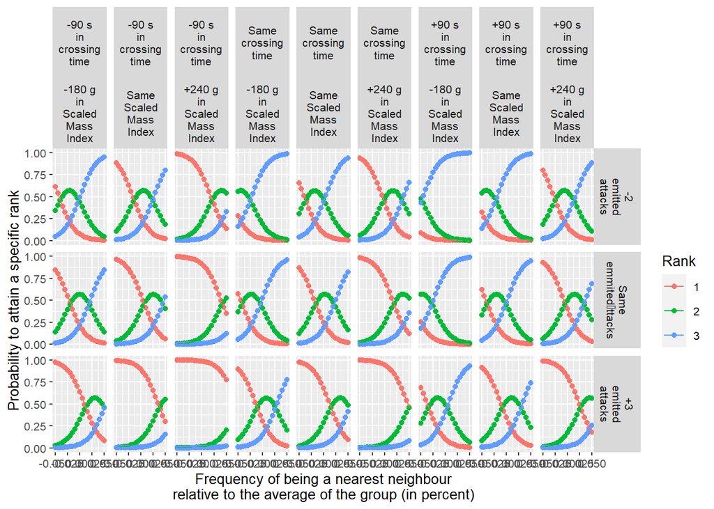

```r
# New data for Set3
newdata_Set3_End <- expand.grid(SMI_rel = seq(from = -180,
                                              to = 240,
                                              by = 20),
                                PrD_Emi_rel = seq(from = -2,
                                                  to = 3,
                                                  by = 0.1),
                                LTi_rel = seq(from = -90,
                                              to = 90,
                                              by = 10),
                                FNN_rel = seq(from = -0.05,
                                              to = 0.05,
                                              by = 0.005))

# the next two lines enable to report the data on the unscaled units
newdata_Set3_End$SMI_rel_s <- (newdata_Set3_End$SMI_rel - mean(Set3_nf$SMI_rel)) / sd(Set3$SMI_rel)
newdata_Set3_End$PrD_Emi_rel_s <- (newdata_Set3_End$PrD_Emi_rel - mean(Set3_nf$PrD_Emi_rel)) / sd(Set3_nf$PrD_Emi_rel)
newdata_Set3_End$LTi_rel_s <- (newdata_Set3_End$LTi_rel - mean(Set3_nf$LTi_rel)) / sd(Set3_nf$LTi_rel)
newdata_Set3_End$FNN_rel_s <- (newdata_Set3_End$FNN_rel - mean(Set3_nf$FNN_rel)) / sd(Set3_nf$FNN_rel)


# Predict values for Set3
predict_Set3_End <- sapply(as.character(1:3),
                       function(x) {
                         newdata1 = expand.grid(SMI_rel_s = seq(from = min(newdata_Set3_End$SMI_rel_s),
                                                                to = max(newdata_Set3_End$SMI_rel_s),
                                                                by = (20 - mean(Set3_nf$SMI_rel)) / sd(Set3_nf$SMI_rel)),
                                                PrD_Emi_rel_s = seq(from = min(newdata_Set3_End$PrD_Emi_rel_s),
                                                                to = max(newdata_Set3_End$PrD_Emi_rel_s),
                                                                by = (0.1 - mean(Set3_nf$PrD_Emi_rel)) / sd(Set3_nf$PrD_Emi_rel)),
                                                LTi_rel_s = seq(from = min(newdata_Set3_End$LTi_rel_s),
                                                                to = max(newdata_Set3_End$LTi_rel_s),
                                                                by = (10 - mean(Set3_nf$LTi_rel)) / sd(Set3_nf$LTi_rel)),
                                                FNN_rel_s = seq(from = min(newdata_Set3_End$FNN_rel_s),
                                                                to = max(newdata_Set3_End$FNN_rel_s),
                                                                by = (0.005 - mean(Set3_nf$FNN_rel)) / sd(Set3_nf$FNN_rel)),
                                                OrderEnd = factor(x, levels = levels(Set3$OrderEnd)))
                         predict(CLMM2_End_S3_min, newdata = newdata1) })

# bind together the new data and the predicted values
predict_Set3_End <- cbind(newdata_Set3_End, predict_Set3_End)

# pass the dataframe in a long format
predict_Set3_End <- predict_Set3_End %>%
  gather("1", "2", "3", key = "Rank", value = "prob")


# produce the graph
predict_Set3_Endbis <- predict_Set3_End %>%
  filter((LTi_rel == min(LTi_rel) |
            LTi_rel == 0 |
            LTi_rel == max(LTi_rel)) &
           (PrD_Emi_rel == min(PrD_Emi_rel) |
              PrD_Emi_rel == 0 |
              PrD_Emi_rel == max(PrD_Emi_rel)) &
           (SMI_rel == min(SMI_rel) |
              SMI_rel == 0 |
              SMI_rel == max(SMI_rel)))

LTi.labs <- c("-90 s\nin\ncrossing\ntime", "Same\ncrossing\ntime", "+90 s\nin\ncrossing\ntime")
names(LTi.labs) <- c("-90", "0", "90")
PrD_Emi.labs <- c("-2\nemitted\nattacks", "Same\nemmited\attacks", "+3\nemitted\nattacks")
names(PrD_Emi.labs) <- c("-2", "0", "3")
SMI.labs <- c("-180 g\nin\nScaled\nMass\nIndex", "Same\nScaled\nMass\nIndex", "+240 g\nin\nScaled\nMass\nIndex")
names(SMI.labs) <- c("-180", "0", "240")


predict_Set3_Endbis %>%
  ggplot(aes(x = FNN_rel, y = prob, colour = Rank)) +
  geom_point() +
  geom_line() +
  facet_grid(PrD_Emi_rel ~ LTi_rel + SMI_rel,
             labeller = labeller(LTi_rel = LTi.labs, PrD_Emi_rel = PrD_Emi.labs, SMI_rel = SMI.labs)) +
  labs(x = "Frequency of being a nearest neighbour\nrelative to the average of the group (in percent)",
       y = "Probability to attain a specific rank") +
  theme_gray(base_size = 10)
```

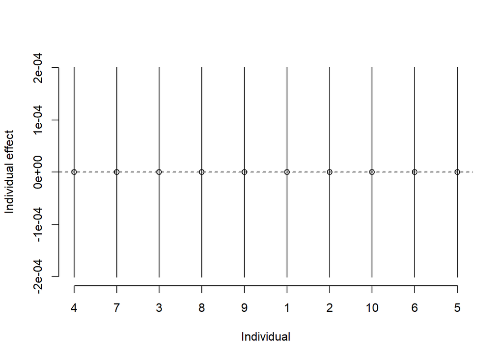

```r
# random effect for Set3 End order
ci_Set3_End <- CLMM2_End_S3_min$ranef + qnorm(0.975) * sqrt(CLMM2_End_S3_min$condVar) %o% c(-1, 1)
ord.re_Set3_End <- order(CLMM2_End_S3_min$ranef)
ci_Set3_End <- ci_Set3_End[order(CLMM2_End_S3_min$ranef), ]
plot(1:10, CLMM2_End_S3_min$ranef[ord.re_Set3_End], axes = FALSE, ylim = range(ci_Set3_End), xlab = "Individual", ylab = "Individual effect")
axis(1, at = 1:10, labels = ord.re_Set3_End)
axis(2)
for(i in 1:10) segments(i, ci_Set3_End[i, 1], i, ci_Set3_End[i, 2])
abline(h = 0, lty = 2)
```